# STAT 207 Final Project - Spotify Top 200

### Group Member

1. Chulong Cheng
2. Minjae Gil
3. Junseok Yang

## 1. Introduction

### Title: Underlying Trends from Spotify Top 200 Chart

### Description of the Original Dataset

(https://www.kaggle.com/sashankpillai/spotify-top-200-charts-20202021)

The dataset include all the songs that have been on the Top 200 Weekly (Global) charts of Spotify in 2020 & 2021.

The dataset include the following features:

- **Highest Charting Position**: The highest position that the song has been on in the Spotify Top 200 Weekly Global Charts in 2020 & 2021.
- **Number of Times Charted**: The number of times that the song has been on in the Spotify Top 200 Weekly Global Charts in 2020 & 2021.
- **Week of Highest Charting**: The week when the song had the Highest Position in the Spotify Top 200 Weekly Global Charts in 2020 & 2021.
- **Song Name**: Name of the song that has been on in the Spotify Top 200 Weekly Global Charts in 2020 & 2021.
- **Song iD**: The song ID provided by Spotify (unique to each song).
- **Streams**: Approximate number of streams the song has.
- **Artist**: The main artist/ artists involved in making the song.
- **Artist Followers**: The number of followers the main artist has on Spotify.
- **Genre**: The genres the song belongs to.
- **Release Date**: The initial date that the song was released.
- **Weeks Charted**: The weeks that the song has been on in the Spotify Top 200 Weekly Global Charts in 2020 & 2021.
- **Popularity**:The popularity of the track. The value will be between 0 and 100, with 100 being the most popular.
- **Danceability**: Danceability describes how suitable a track is for dancing based on a combination of musical elements including tempo, rhythm stability, beat strength, and overall regularity. A value of 0.0 is least danceable and 1.0 is most danceable.
- **Acousticness**: A measure from 0.0 to 1.0 of whether the track is acoustic.
- **Energy**: Energy is a measure from 0.0 to 1.0 and represents a perceptual measure of intensity and activity. Typically, energetic tracks feel fast, loud, and noisy.
- **Instrumentalness**: Predicts whether a track contains no vocals. The closer the instrumentalness value is to 1.0, the greater likelihood the track contains no vocal content.
- **Liveness**: Detects the presence of an audience in the recording. Higher liveness values represent an increased probability that the track was performed live.
- **Loudness**: The overall loudness of a track in decibels (dB). Loudness values are averaged across the entire track. Values typical range between -60 and 0 db.
- **Speechiness:** Speechiness detects the presence of spoken words in a track. The more exclusively speech-like the recording (e.g. talk show, audio book, poetry), the closer to 1.0 the attribute value.
- **Tempo**: The overall estimated tempo of a track in beats per minute (BPM). In musical terminology, tempo is the speed or pace of a given piece and derives directly from the average beat duration.
- **Valence**: A measure from 0.0 to 1.0 describing the musical positiveness conveyed by a track. Tracks with high valence sound more positive (e.g. happy, cheerful, euphoric), while tracks with low valence sound more negative (e.g. sad, depressed, angry).
- **Chord**: The main chord of the song instrumental.

*Acknowledgements*

This dataset would not be possible without the help of spotifycharts.com and Spotipy Python Library

There are total unique values of 1556.

### Description of the Sampled Dataset

**Spotify Dataset** (spotify_top_200_sample.csv)

- This is a random sample of song attributes for songs that have been on the Top 200 Weekly Global charts of Spotify in the years 2020 and 2021.

### Motivation

- From the Spotify Top 200 songs chart, we would like to figure out whether there is interesting underlying trends between various attributes given in the dataset.

### Research Questions

1. What would be a relationship between a song's **'Energy'** and the number of **'Streams'**? Moreover, would there be any additional significant association between these two variables when grouping by four different **'seasons'**?
2. Is there a difference of a song's tempo by different seasons (Specifically between summer and fall)?
3. Is there a linear relationship between a song's highest chart ranking and the song's artist features in the sample?
4. Can we detect any noticeable association between 'hip hop' or 'rap' songs and their music components? Plus, can we accurately predict whether a song is hip hop or not based on its music components?

### 1.1 Imports

```python
import pandas as pd
import matplotlib.pyplot as plt
import numpy as np
import seaborn as sns

import warnings
warnings.filterwarnings("ignore")
```

### 1.2 Data Processing & Cleaning

```python
# Random sample of the original dataset
df = pd.read_csv("spotify_top_200_sample.csv")
df
```

|  | Highest_Charting_Position | Number_of_Times_Charted | Week_of_Highest_Charting | Week_of_Highest_Charting_year | Week_of_Highest_Charting_month | Week_of_Highest_Charting_day | Song_Name | Streams | Artist | Artist_Followers | ... | Genre_2 | Genre_3 | Genre_4 | Genre_5 | Genre_6 | Genre_7 | Genre_8 | Genre_9 | Genre_10 | Genre_11 |
| --- | --- | --- | --- | --- | --- | --- | --- | --- | --- | --- | --- | --- | --- | --- | --- | --- | --- | --- | --- | --- | --- |
| 0 | 8 | 24 | 4/2/2021 | 2021 | 4 | 2 | Heartbreak Anniversary | 8832945 | Giveon | 1398563 | ... | r&b | NaN | NaN | NaN | NaN | NaN | NaN | NaN | NaN | NaN |
| 1 | 92 | 2 | 5/15/2020 | 2020 | 5 | 15 | X (with KAROL G) | 5018592 | Jonas Brothers | 5436999 | ... | dance pop | pop | post-teen pop | NaN | NaN | NaN | NaN | NaN | NaN | NaN |
| 2 | 181 | 1 | 12/18/2020 | 2020 | 12 | 18 | Christmas Tree Farm | 6657404 | Taylor Swift | 42227614 | ... | post-teen pop | NaN | NaN | NaN | NaN | NaN | NaN | NaN | NaN | NaN |
| 3 | 12 | 29 | 11/27/2020 | 2020 | 11 | 27 | TE MUDASTE | 5242347 | Bad Bunny | 36142273 | ... | reggaeton | trap latino | NaN | NaN | NaN | NaN | NaN | NaN | NaN | NaN |
| 4 | 32 | 10 | 1/3/2020 | 2020 | 1 | 3 | Futsal Shuffle 2020 | 5386512 | Lil Uzi Vert | 11821805 | ... | philly rap | rap | trap | NaN | NaN | NaN | NaN | NaN | NaN | NaN |
| ... | ... | ... | ... | ... | ... | ... | ... | ... | ... | ... | ... | ... | ... | ... | ... | ... | ... | ... | ... | ... | ... |
| 495 | 30 | 9 | 4/10/2020 | 2020 | 4 | 10 | Level of Concern | 4252898 | Twenty One Pilots | 20829526 | ... | rock | NaN | NaN | NaN | NaN | NaN | NaN | NaN | NaN | NaN |
| 496 | 29 | 15 | 1/24/2020 | 2020 | 1 | 24 | What If I Told You That I Love You | 5234645 | Ali Gatie | 1758300 | ... | pop | NaN | NaN | NaN | NaN | NaN | NaN | NaN | NaN | NaN |
| 497 | 193 | 1 | 2/12/2021 | 2021 | 2 | 12 | Wonderwall | 4902737 | Oasis | 6478565 | ... | britpop | madchester | permanent wave | rock | NaN | NaN | NaN | NaN | NaN | NaN |
| 498 | 6 | 7 | 12/18/2020 | 2020 | 12 | 18 | It's Beginning to Look a Lot like Christmas | 15424001 | Michael Bublé | 4702232 | ... | canadian pop | jazz pop | lounge | NaN | NaN | NaN | NaN | NaN | NaN | NaN |
| 499 | 124 | 3 | 11/6/2020 | 2020 | 11 | 6 | Sweet Melody | 5201322 | Little Mix | 9398941 | ... | girl group | pop | post-teen pop | talent show | uk pop | NaN | NaN | NaN | NaN | NaN |

500 rows × 41 columns

```python
# Show all columns in the dataframe
pd.set_option('display.max_columns', None)
df.head()
```

|  | Highest_Charting_Position | Number_of_Times_Charted | Week_of_Highest_Charting | Week_of_Highest_Charting_year | Week_of_Highest_Charting_month | Week_of_Highest_Charting_day | Song_Name | Streams | Artist | Artist_Followers | Song_ID | Release_Date | Release_Date_year | Release_Date_month | Release_Date_day | Weeks_Charted | Weeks_Charted_year | Weeks_Charted_month | Weeks_Charted_day | Popularity | Danceability | Energy | Loudness | Speechiness | Acousticness | Liveness | Tempo | Duration_ms | Valence | … |
| --- | --- | --- | --- | --- | --- | --- | --- | --- | --- | --- | --- | --- | --- | --- | --- | --- | --- | --- | --- | --- | --- | --- | --- | --- | --- | --- | --- | --- | --- | --- |
| 0 | 8 | 24 | 4/2/2021 | 2021 | 4 | 2 | Heartbreak Anniversary | 8832945 | Giveon | 1398563 | 3FAJ6O0NOHQV8Mc5Ri6ENp | 3/27/2020 | 2020.0 | 3 | 27.0 | 7/23/2021 | 2021 | 7 | 23 | 87 | 0.449 | 0.465 | -8.964 | 0.079 | 0.524 | 0.303 | 89.087 | 198371 | 0.543 | … |
| 1 | 92 | 2 | 5/15/2020 | 2020 | 5 | 15 | X (with KAROL G) | 5018592 | Jonas Brothers | 5436999 | 77fvnWALKJR0ws1VUx09CY | 5/15/2020 | 2020.0 | 5 | 15.0 | 5/22/2020 | 2020 | 5 | 22 | 70 | 0.715 | 0.827 | -5.09 | 0.062 | 0.049 | 0.321 | 117.977 | 185277 | 0.75 | … |
| 2 | 181 | 1 | 12/18/2020 | 2020 | 12 | 18 | Christmas Tree Farm | 6657404 | Taylor Swift | 42227614 | 2mvabkN1i2gLnGAPUVdwek | 12/6/2019 | 2019.0 | 12 | 6.0 | 12/18/2020 | 2020 | 12 | 18 | 52 | 0.598 | 0.68 | -4.505 | 0.033 | 0.06 | 0.324 | 134.002 | 228027 | 0.437 | … |
| 3 | 12 | 29 | 11/27/2020 | 2020 | 11 | 27 | TE MUDASTE | 5242347 | Bad Bunny | 36142273 | 5RubKOuDoPn5Kj5TLVxSxY | 11/27/2020 | 2020.0 | 11 | 27.0 | 6/11/2021 | 2021 | 6 | 11 | 82 | 0.811 | 0.637 | -4.835 | 0.059 | 0.234 | 0.118 | 92.025 | 130014 | 0.471 | … |
| 4 | 32 | 10 | 1/3/2020 | 2020 | 1 | 3 | Futsal Shuffle 2020 | 5386512 | Lil Uzi Vert | 11821805 | 2Ec33AVlkTTq8BHFgBTdQs | 12/12/2019 | 2019.0 | 12 | 12.0 | 2/28/2020 | 2020 | 2 | 28 | 67 | 0.881 | 0.457 | -8.191 | 0.156 | 0.033 | 0.231 | 136.97 | 198913 | 0.296 | … |

```python
df.dtypes
```

```
Highest_Charting_Position           int64
Number_of_Times_Charted             int64
Week_of_Highest_Charting           object
Week_of_Highest_Charting_year       int64
Week_of_Highest_Charting_month      int64
Week_of_Highest_Charting_day        int64
Song_Name                          object
Streams                             int64
Artist                             object
Artist_Followers                   object
Song_ID                            object
Release_Date                       object
Release_Date_year                 float64
Release_Date_month                 object
Release_Date_day                  float64
Weeks_Charted                      object
Weeks_Charted_year                  int64
Weeks_Charted_month                 int64
Weeks_Charted_day                   int64
Popularity                         object
Danceability                       object
Energy                             object
Loudness                           object
Speechiness                        object
Acousticness                       object
Liveness                           object
Tempo                              object
Duration_ms                        object
Valence                            object
Chord                              object
Genre_1                            object
Genre_2                            object
Genre_3                            object
Genre_4                            object
Genre_5                            object
Genre_6                            object
Genre_7                            object
Genre_8                            object
Genre_9                            object
Genre_10                           object
Genre_11                           object
dtype: object
```

Since there are some attributes labeled incorrectly, we need to check these attributes' unique values to see whether there are missing values.

```python
check_list = ['Popularity', 'Danceability', 'Energy', 'Loudness', 'Speechiness', 'Acousticness', 'Liveness', 'Tempo', 'Duration_ms', 'Valence']

for col in check_list:
    print('Unique Values of %s'%(col))
    print(df[col].unique())
    print(df[col].dtypes)
    print('-----------------------------')
```

```
Unique Values of Popularity
['87' '70' '52' '82' '67' '68' '75' '78' '71' '62' '84' '66' '95' '56'
 '72' '85' '73' '0' '83' '53' '86' '74' '79' '80' '47' '90' '69' '58' '63'
 '92' '55' '77' '49' '76' '61' 'missing' '60' '81' '89' '29' '51' '50'
 '54' '64' '57' '59' '65' '44' '41' '42' '36' '45' '88' '3' '96' '46']
object
-----------------------------
Unique Values of Danceability
['0.449' '0.715' '0.598' '0.811' '0.881' '0.385' '0.483' '0.62' '0.801'
 '0.784' '0.694' '0.586' '0.75' '0.758' '0.825' '0.788' '0.703' '0.713'
 '0.686' '0.82' '0.593' '0.817' '0.701' '0.611' '0.485' '0.625' '0.74'
 '0.624' '0.764' '0.775' '0.575' '0.816' '0.712' '0.85' '0.845' '0.683'
 '0.668' '0.499' '0.789' '0.761' '0.806' '0.781' '0.691' '0.957' '0.476'
 '0.961' '0.808' '0.763' 'missing' '0.692' '0.956' '0.676' '0.553' '0.522'
 '0.631' '0.821' '0.848' '0.851' '0.729' '0.474' '0.604' '0.574' '0.843'
 '0.812' '0.607' '0.883' '0.552' '0.826' '0.567' '0.656' '0.375' '0.584'
 '0.787' '0.81' '0.548' '0.73' '0.556' '0.832' '0.616' '0.876' '0.448'
 '0.846' '0.749' '0.838' '0.557' '0.762' '0.934' '0.719' '0.741' '0.721'
 '0.847' '0.72' '0.509' '0.827' '0.487' '0.738' '0.796' '0.756' '0.391'
 '0.534' '0.855' '0.89' '0.664' '0.614' '0.852' '0.887' '0.532' '0.464'
 '0.745' '0.559' '0.768' '0.86' '0.679' '0.654' '0.859' '0.795' '0.807'
 '0.331' '0.689' '0.661' '0.793' '0.386' '0.839' '0.834' '0.595' '0.613'
 '0.579' '0.457' '0.653' '0.948' '0.523' '0.558' '0.709' '0.68' '0.657'
 '0.612' '0.665' '0.831' '0.599' '0.629' '0.526' '0.54' '0.462' '0.662'
 '0.528' '0.733' '0.702' '0.638' '0.797' '0.716' '0.727' '0.589' '0.658'
 '0.576' '0.501' '0.585' '0.754' '0.402' '0.15' '0.484' '0.65' '0.722'
 '0.618' '0.469' '0.927' '0.769' '0.824' '0.666' '0.94' '0.582' '0.688'
 '0.563' '0.535' '0.63' '0.356' '0.447' '0.357' '0.862' '0.478' '0.59'
 '0.907' '0.737' '0.766' '0.771' '0.632' '0.307' '0.863' '0.774' '0.901'
 '0.916' '0.323' '0.735' '0.752' '0.634' '0.799' '0.739' '0.413' '0.514'
 '0.633' '0.9' '0.411' '0.804' '0.871' '0.524' '0.641' '0.56' '0.521'
 '0.652' '0.41' '0.695' '0.83' '0.677' '0.445' '0.667' '0.744' '0.646'
 '0.648' '0.591' '0.512' '0.882' '0.645' '0.708' '0.647' '0.786' '0.376'
 '0.76' '0.903' '0.621' '0.728' '0.663' '0.785' '0.746' '0.759' '0.351'
 '0.317' '0.609' '0.867' '0.627' '0.71' '0.592' '0.849' '0.473' '0.865'
 '0.538' '0.551' '0.718' '0.724' '0.364' '0.747' '0.271' '0.944' '0.333'
 '0.674' '0.772' '0.685' '0.837' '0.906' '0.61' '0.705' '0.467' '0.343'
 '0.681' '0.889' '0.841' '0.572' '0.47' '0.537' '0.321' '0.912' '0.95'
 '0.935' '0.403' '0.596' '0.468' '0.779' '0.352' '0.399' '0.736' '0.742'
 '0.619' '0.642' '0.776' '0.477' '0.856' '0.672' '0.88' '0.905' '0.438'
```

[output cut: 376 more lines]

```
 '0.658' '0.627' '0.207' '0.505' '0.495' '0.374' '0.064' '0.618' '0.659'
 '0.366' '0.581' '0.428' '0.769' '0.234' '0.517' '0.456' '0.761' '0.824'
 '0.307' '0.271' '0.728' '0.583' '0.108' '0.962' '0.032' '0.429' '0.716'
 '0.704' '0.292' '0.601' '0.74' '0.201' '0.489' '0.414' '0.497' '0.886'
 '0.473' '0.285' '0.635' '0.745' '0.734' '0.152' '0.289' '0.39' '0.675'
 '0.894' '0.547' '0.266' '0.558' '0.09' '0.8' '0.43' '0.666' '0.699'
 '0.192' '0.586' '0.506' '0.367' '0.449' '0.295' '0.331' '0.654' '0.158'
 '0.188' '0.463' '0.383' '0.92' '0.349' '0.835' '0.61' '0.608' '0.499'
 '0.396' '0.585' '0.176' '0.175' '0.804' '0.577' '0.821' '0.074' '0.691'
 '0.411' '0.318' '0.259' '0.548' '0.887' '0.191' '0.946' '0.494' '0.697'
 '0.724' '0.553' '0.623' '0.842' '0.351' '0.395' '0.468' '0.828' '0.401'
 '0.36' '0.648' '0.636' '0.865' '0.683' '0.052' '0.372' '0.438' '0.537'
 '0.873' '0.774' '0.229' '0.434' '0.363' '0.419']
object
-----------------------------
```

We can find out that there are some 'missing' values in the dataset, therefore need to read the dataset again with replacing 'missing' values to 'NaN'.

```python
missing_value = ['missing']

df = pd.read_csv("spotify_top_200_sample.csv", na_values = missing_value)
df.dtypes
```

```
Highest_Charting_Position           int64
Number_of_Times_Charted             int64
Week_of_Highest_Charting           object
Week_of_Highest_Charting_year       int64
Week_of_Highest_Charting_month      int64
Week_of_Highest_Charting_day        int64
Song_Name                          object
Streams                             int64
Artist                             object
Artist_Followers                  float64
Song_ID                            object
Release_Date                       object
Release_Date_year                 float64
Release_Date_month                 object
Release_Date_day                  float64
Weeks_Charted                      object
Weeks_Charted_year                  int64
Weeks_Charted_month                 int64
Weeks_Charted_day                   int64
Popularity                        float64
Danceability                      float64
Energy                            float64
Loudness                          float64
Speechiness                       float64
Acousticness                      float64
Liveness                          float64
Tempo                             float64
Duration_ms                       float64
Valence                           float64
Chord                              object
Genre_1                            object
Genre_2                            object
Genre_3                            object
Genre_4                            object
Genre_5                            object
Genre_6                            object
Genre_7                            object
Genre_8                            object
Genre_9                            object
Genre_10                           object
Genre_11                           object
dtype: object
```

Now we can see that the columns' data types are labeled correctly.

There are too many genre columns, hence leave only **'Genre_1'** and drop the rest genre columns.

```python
for i in range(2, 12):
    df = df.drop(['Genre_%s'%(i)], axis = 1)
```

```python
df.shape
```

```
(500, 31)
```

```python
# Check the number of NaN values in every attributes

df.isna().sum()
```

```
Highest_Charting_Position          0
Number_of_Times_Charted            0
Week_of_Highest_Charting           0
Week_of_Highest_Charting_year      0
Week_of_Highest_Charting_month     0
Week_of_Highest_Charting_day       0
Song_Name                          0
Streams                            0
Artist                             0
Artist_Followers                   4
Song_ID                            0
Release_Date                       0
Release_Date_year                 12
Release_Date_month                 0
Release_Date_day                  12
Weeks_Charted                      0
Weeks_Charted_year                 0
Weeks_Charted_month                0
Weeks_Charted_day                  0
Popularity                         4
Danceability                       4
Energy                             4
Loudness                           4
Speechiness                        4
Acousticness                       4
Liveness                           4
Tempo                              4
Duration_ms                        4
Valence                            4
Chord                              0
Genre_1                           22
dtype: int64
```

```python
df = df.dropna()
df.shape
```

```
(467, 31)
```

## 2. Descriptive Analytics

What would be a relationship between a song's **'Energy'** and the number of **'Streams'**? Moreover, would there be any additional significant association between these two variables when grouping by four different **'seasons'**? (The month that the song was released)

```python
df.head()
```

|  | Highest_Charting_Position | Number_of_Times_Charted | Week_of_Highest_Charting | Week_of_Highest_Charting_year | Week_of_Highest_Charting_month | Week_of_Highest_Charting_day | Song_Name | Streams | Artist | Artist_Followers | Song_ID | Release_Date | Release_Date_year | Release_Date_month | Release_Date_day | Weeks_Charted | Weeks_Charted_year | Weeks_Charted_month | Weeks_Charted_day | Popularity | Danceability | Energy | Loudness | Speechiness | Acousticness | Liveness | Tempo | Duration_ms | Valence | … |
| --- | --- | --- | --- | --- | --- | --- | --- | --- | --- | --- | --- | --- | --- | --- | --- | --- | --- | --- | --- | --- | --- | --- | --- | --- | --- | --- | --- | --- | --- | --- |
| 0 | 8 | 24 | 4/2/2021 | 2021 | 4 | 2 | Heartbreak Anniversary | 8832945 | Giveon | 1398563.0 | 3FAJ6O0NOHQV8Mc5Ri6ENp | 3/27/2020 | 2020.0 | 3 | 27.0 | 7/23/2021 | 2021 | 7 | 23 | 87.0 | 0.449 | 0.465 | -8.964 | 0.079 | 0.524 | 0.303 | 89.087 | 198371.0 | 0.543 | … |
| 1 | 92 | 2 | 5/15/2020 | 2020 | 5 | 15 | X (with KAROL G) | 5018592 | Jonas Brothers | 5436999.0 | 77fvnWALKJR0ws1VUx09CY | 5/15/2020 | 2020.0 | 5 | 15.0 | 5/22/2020 | 2020 | 5 | 22 | 70.0 | 0.715 | 0.827 | -5.090 | 0.062 | 0.049 | 0.321 | 117.977 | 185277.0 | 0.750 | … |
| 2 | 181 | 1 | 12/18/2020 | 2020 | 12 | 18 | Christmas Tree Farm | 6657404 | Taylor Swift | 42227614.0 | 2mvabkN1i2gLnGAPUVdwek | 12/6/2019 | 2019.0 | 12 | 6.0 | 12/18/2020 | 2020 | 12 | 18 | 52.0 | 0.598 | 0.680 | -4.505 | 0.033 | 0.060 | 0.324 | 134.002 | 228027.0 | 0.437 | … |
| 3 | 12 | 29 | 11/27/2020 | 2020 | 11 | 27 | TE MUDASTE | 5242347 | Bad Bunny | 36142273.0 | 5RubKOuDoPn5Kj5TLVxSxY | 11/27/2020 | 2020.0 | 11 | 27.0 | 6/11/2021 | 2021 | 6 | 11 | 82.0 | 0.811 | 0.637 | -4.835 | 0.059 | 0.234 | 0.118 | 92.025 | 130014.0 | 0.471 | … |
| 4 | 32 | 10 | 1/3/2020 | 2020 | 1 | 3 | Futsal Shuffle 2020 | 5386512 | Lil Uzi Vert | 11821805.0 | 2Ec33AVlkTTq8BHFgBTdQs | 12/12/2019 | 2019.0 | 12 | 12.0 | 2/28/2020 | 2020 | 2 | 28 | 67.0 | 0.881 | 0.457 | -8.191 | 0.156 | 0.033 | 0.231 | 136.970 | 198913.0 | 0.296 | … |

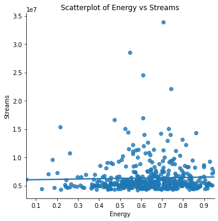

```python
plt.figure(figsize=(15, 8))
sns.lmplot(x = 'Energy', y = 'Streams', data = df, ci = False)
plt.title("Scatterplot of Energy vs Streams")
plt.show()
```

From the following scatterplot of the relationship between only **'Streams'** and **'Energy'**, which is about the intensity of a song, or how energetic and powerful a song is, we can see that there is no noticeable association between **'Energy'** and **'Streams'**.

Since we do not have a column **'seasons'** in the dataset yet, we have to add the column. Below is the code of adding **'Seasons'** column.

(Spring: Mar/Apr/May, Summer: Jun/Jul/Aug, Fall: Sep/Oct/Nov, Winter: Dec/Jan/Feb)

```python
df['seasons'] = ""

for i in range(len(df)):
    if (df['Release_Date_month'].iloc[i] == '3')|(df['Release_Date_month'].iloc[i] == '4')|(df['Release_Date_month'].iloc[i] == '5'):
        df['seasons'].iloc[i] = 'spring'
    elif (df['Release_Date_month'].iloc[i] == '6')|(df['Release_Date_month'].iloc[i] == '7')|(df['Release_Date_month'].iloc[i] == '8'):
        df['seasons'].iloc[i] = 'summer'
    elif (df['Release_Date_month'].iloc[i] == '9')|(df['Release_Date_month'].iloc[i] == '10')|(df['Release_Date_month'].iloc[i] == '11'):
        df['seasons'].iloc[i] = 'fall'
    else:
        df['seasons'].iloc[i] = 'winter'
```

```python
df.head()
```

|  | Highest_Charting_Position | Number_of_Times_Charted | Week_of_Highest_Charting | Week_of_Highest_Charting_year | Week_of_Highest_Charting_month | Week_of_Highest_Charting_day | Song_Name | Streams | Artist | Artist_Followers | Song_ID | Release_Date | Release_Date_year | Release_Date_month | Release_Date_day | Weeks_Charted | Weeks_Charted_year | Weeks_Charted_month | Weeks_Charted_day | Popularity | Danceability | Energy | Loudness | Speechiness | Acousticness | Liveness | Tempo | Duration_ms | Valence | … |
| --- | --- | --- | --- | --- | --- | --- | --- | --- | --- | --- | --- | --- | --- | --- | --- | --- | --- | --- | --- | --- | --- | --- | --- | --- | --- | --- | --- | --- | --- | --- |
| 0 | 8 | 24 | 4/2/2021 | 2021 | 4 | 2 | Heartbreak Anniversary | 8832945 | Giveon | 1398563.0 | 3FAJ6O0NOHQV8Mc5Ri6ENp | 3/27/2020 | 2020.0 | 3 | 27.0 | 7/23/2021 | 2021 | 7 | 23 | 87.0 | 0.449 | 0.465 | -8.964 | 0.079 | 0.524 | 0.303 | 89.087 | 198371.0 | 0.543 | … |
| 1 | 92 | 2 | 5/15/2020 | 2020 | 5 | 15 | X (with KAROL G) | 5018592 | Jonas Brothers | 5436999.0 | 77fvnWALKJR0ws1VUx09CY | 5/15/2020 | 2020.0 | 5 | 15.0 | 5/22/2020 | 2020 | 5 | 22 | 70.0 | 0.715 | 0.827 | -5.090 | 0.062 | 0.049 | 0.321 | 117.977 | 185277.0 | 0.750 | … |
| 2 | 181 | 1 | 12/18/2020 | 2020 | 12 | 18 | Christmas Tree Farm | 6657404 | Taylor Swift | 42227614.0 | 2mvabkN1i2gLnGAPUVdwek | 12/6/2019 | 2019.0 | 12 | 6.0 | 12/18/2020 | 2020 | 12 | 18 | 52.0 | 0.598 | 0.680 | -4.505 | 0.033 | 0.060 | 0.324 | 134.002 | 228027.0 | 0.437 | … |
| 3 | 12 | 29 | 11/27/2020 | 2020 | 11 | 27 | TE MUDASTE | 5242347 | Bad Bunny | 36142273.0 | 5RubKOuDoPn5Kj5TLVxSxY | 11/27/2020 | 2020.0 | 11 | 27.0 | 6/11/2021 | 2021 | 6 | 11 | 82.0 | 0.811 | 0.637 | -4.835 | 0.059 | 0.234 | 0.118 | 92.025 | 130014.0 | 0.471 | … |
| 4 | 32 | 10 | 1/3/2020 | 2020 | 1 | 3 | Futsal Shuffle 2020 | 5386512 | Lil Uzi Vert | 11821805.0 | 2Ec33AVlkTTq8BHFgBTdQs | 12/12/2019 | 2019.0 | 12 | 12.0 | 2/28/2020 | 2020 | 2 | 28 | 67.0 | 0.881 | 0.457 | -8.191 | 0.156 | 0.033 | 0.231 | 136.970 | 198913.0 | 0.296 | … |

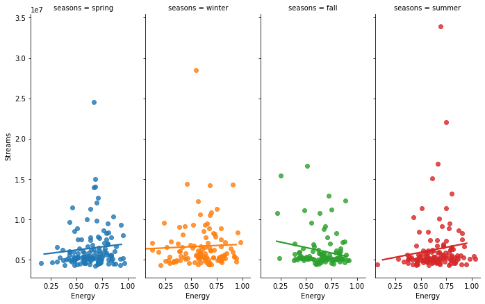

```python
plt.figure(figsize=(30, 15))
sns.lmplot(x = 'Energy', y = 'Streams', hue = 'seasons',col = 'seasons', height=6, aspect=.4, x_jitter=.1, data = df, ci = False)
plt.show()
```

```python
df.groupby(['seasons'])[['Energy']].describe()
```

| seasons | Energy count | Energy mean | Energy std | Energy min | Energy 25% | Energy 50% | Energy 75% | Energy max |
| --- | --- | --- | --- | --- | --- | --- | --- | --- |
| fall | 101.0 | 0.645149 | 0.148752 | 0.214 | 0.54200 | 0.640 | 0.758 | 0.904 |
| spring | 125.0 | 0.637504 | 0.157339 | 0.186 | 0.54500 | 0.632 | 0.748 | 0.939 |
| summer | 129.0 | 0.640287 | 0.149718 | 0.128 | 0.53100 | 0.648 | 0.740 | 0.948 |
| winter | 112.0 | 0.597196 | 0.187088 | 0.054 | 0.48975 | 0.633 | 0.731 | 0.938 |

```python
df.groupby(['seasons'])[['Streams']].describe()
```

| seasons | Streams count | Streams mean | Streams std | Streams min | Streams 25% | Streams 50% | Streams 75% | Streams max |
| --- | --- | --- | --- | --- | --- | --- | --- | --- |
| fall | 101.0 | 6.090321e+06 | 2.223230e+06 | 4425610.0 | 5005018.00 | 5242347.0 | 5914661.00 | 16613649.0 |
| spring | 125.0 | 6.394110e+06 | 2.702761e+06 | 4252898.0 | 4966878.00 | 5383125.0 | 6809438.00 | 24551591.0 |
| summer | 129.0 | 6.245144e+06 | 3.473929e+06 | 4314080.0 | 4900492.00 | 5228433.0 | 6144736.00 | 33948454.0 |
| winter | 112.0 | 6.647179e+06 | 2.976003e+06 | 4293009.0 | 5114516.25 | 5701746.5 | 7077461.75 | 28509534.0 |

By categorizing songs by four different seasons, it is interesting that only fall season songs seem to show a negative correlation between **'Energy'** and **'Streams'**, indicating that songs released in fall with lower energy tend to be favored more by people.

## 3. Inference

### Research Question

Is there a difference of a song's tempo by different seasons (Specifically between summer and fall)?

### Hypothesis

- $H_0: \mu_{Summer} = \mu_{Fall}$
- $H_A: \mu_{Summer} \neq \mu_{Fall}$

### Condition Check

1. Random Sample

Since we can find out from our dataset's description, "This is a random sample of song attributes for songs that have been on the Top 200 Weekly Global charts of Spotify in the years 2020 and 2021.", our samples would also be randomly sampled. Thus, this condition is met.

1. $n_1 <$ (10% of the population 1 size), $n_2 < $ (10% of the population 2 size)

```python
len(df[df['seasons'] == 'summer'])
```

```
129
```

```python
len(df[df['seasons'] == 'fall'])
```

```
101
```

The sizes of population 1 (songs released in the summer) and 2 (songs released in the fall) should be at least 1290 and 1010 in order to satisfy the condition. Considering that the overall population size of the dataset is 1556 (check the *acknowledgements* in the introduction), this does not make sense, thus violating the condition.

1. Either...
- $n_1 > 30$, $n_2 > 30$

or

- the population 1 and 2's distributions are normal.

Both the sample sizes are larger than 30, hence this condition is satisfied.

We can see that the second condition is not met. Theoretically, we cannot conduct the hypothesis test, but we will do the test with caution.

Since we do not know the populations' standard deviations ($\sigma_1, \sigma_2$), we instead use the samples' standard deviations ($s_1, s_2$) and use the t-distribution as well.

```python
n_summer = len(df[df['seasons'] == 'summer'])
n_fall = len(df[df['seasons'] == 'fall'])

tempo_summer = df[df['seasons'] == 'summer']['Tempo'].mean()
tempo_fall = df[df['seasons'] == 'fall']['Tempo'].mean()

std_summer = df[df['seasons'] == 'summer']['Tempo'].std()
std_fall = df[df['seasons'] == 'fall']['Tempo'].std()
```

```python
point_est = tempo_summer - tempo_fall
se = ((std_summer**2)/n_summer + (std_fall**2)/n_fall)**0.5

from scipy.stats import t

test_stat = (point_est - 0) / se

p_val = 2 * (1 - t.cdf(abs(test_stat), df = min(n_summer, n_fall)))
p_val
```

```
0.19676903892652442
```

Since the p-value is about 0.20, which is relatively larger than the typical significance level $\alpha = 0.05$, we would fail to reject the null and conclude that there is no average tempo difference of songs by seasons.

## 4. Linear Regression

### Research Question

Is there a linear relationship between a song's highest chart ranking and the song's artist features in the sample?

- Explanatory variables: Number of times charted/Streams/Artist Followers/Popularity
- Response variable: Highest Charting Position

```python
df.head()
```

|  | Highest_Charting_Position | Number_of_Times_Charted | Week_of_Highest_Charting | Week_of_Highest_Charting_year | Week_of_Highest_Charting_month | Week_of_Highest_Charting_day | Song_Name | Streams | Artist | Artist_Followers | Song_ID | Release_Date | Release_Date_year | Release_Date_month | Release_Date_day | Weeks_Charted | Weeks_Charted_year | Weeks_Charted_month | Weeks_Charted_day | Popularity | Danceability | Energy | Loudness | Speechiness | Acousticness | Liveness | Tempo | Duration_ms | Valence | … |
| --- | --- | --- | --- | --- | --- | --- | --- | --- | --- | --- | --- | --- | --- | --- | --- | --- | --- | --- | --- | --- | --- | --- | --- | --- | --- | --- | --- | --- | --- | --- |
| 0 | 8 | 24 | 4/2/2021 | 2021 | 4 | 2 | Heartbreak Anniversary | 8832945 | Giveon | 1398563.0 | 3FAJ6O0NOHQV8Mc5Ri6ENp | 3/27/2020 | 2020.0 | 3 | 27.0 | 7/23/2021 | 2021 | 7 | 23 | 87.0 | 0.449 | 0.465 | -8.964 | 0.079 | 0.524 | 0.303 | 89.087 | 198371.0 | 0.543 | … |
| 1 | 92 | 2 | 5/15/2020 | 2020 | 5 | 15 | X (with KAROL G) | 5018592 | Jonas Brothers | 5436999.0 | 77fvnWALKJR0ws1VUx09CY | 5/15/2020 | 2020.0 | 5 | 15.0 | 5/22/2020 | 2020 | 5 | 22 | 70.0 | 0.715 | 0.827 | -5.090 | 0.062 | 0.049 | 0.321 | 117.977 | 185277.0 | 0.750 | … |
| 2 | 181 | 1 | 12/18/2020 | 2020 | 12 | 18 | Christmas Tree Farm | 6657404 | Taylor Swift | 42227614.0 | 2mvabkN1i2gLnGAPUVdwek | 12/6/2019 | 2019.0 | 12 | 6.0 | 12/18/2020 | 2020 | 12 | 18 | 52.0 | 0.598 | 0.680 | -4.505 | 0.033 | 0.060 | 0.324 | 134.002 | 228027.0 | 0.437 | … |
| 3 | 12 | 29 | 11/27/2020 | 2020 | 11 | 27 | TE MUDASTE | 5242347 | Bad Bunny | 36142273.0 | 5RubKOuDoPn5Kj5TLVxSxY | 11/27/2020 | 2020.0 | 11 | 27.0 | 6/11/2021 | 2021 | 6 | 11 | 82.0 | 0.811 | 0.637 | -4.835 | 0.059 | 0.234 | 0.118 | 92.025 | 130014.0 | 0.471 | … |
| 4 | 32 | 10 | 1/3/2020 | 2020 | 1 | 3 | Futsal Shuffle 2020 | 5386512 | Lil Uzi Vert | 11821805.0 | 2Ec33AVlkTTq8BHFgBTdQs | 12/12/2019 | 2019.0 | 12 | 12.0 | 2/28/2020 | 2020 | 2 | 28 | 67.0 | 0.881 | 0.457 | -8.191 | 0.156 | 0.033 | 0.231 | 136.970 | 198913.0 | 0.296 | … |

```python
import statsmodels.api as sm
import statsmodels.formula.api as smf

mlr = smf.ols('Highest_Charting_Position ~ Number_of_Times_Charted + Streams + Artist_Followers + Popularity', data = df).fit()
mlr.summary()
```

OLS Regression Results

| Dep. Variable: | Highest_Charting_Position | R-squared: | 0.358 |
| --- | --- | --- | --- |
| Model: | OLS | Adj. R-squared: | 0.353 |
| Method: | Least Squares | F-statistic: | 64.47 |
| Date: | Thu, 09 Dec 2021 | Prob (F-statistic): | 2.67e-43 |
| Time: | 21:21:40 | Log-Likelihood: | -2464.0 |
| No. Observations: | 467 | AIC: | 4938. |
| Df Residuals: | 462 | BIC: | 4959. |
| Df Model: | 4 |  |  |
| Covariance Type: | nonrobust |  |  |

|  | coef | std err | t | P>\|t\| | [0.025 | 0.975] |
| --- | --- | --- | --- | --- | --- | --- |
| Intercept | 199.6681 | 17.151 | 11.642 | 0.000 | 165.964 | 233.372 |
| Number_of_Times_Charted | -1.3551 | 0.151 | -8.963 | 0.000 | -1.652 | -1.058 |
| Streams | -6.322e-06 | 7.7e-07 | -8.213 | 0.000 | -7.83e-06 | -4.81e-06 |
| Artist_Followers | -6.663e-07 | 1.27e-07 | -5.248 | 0.000 | -9.16e-07 | -4.17e-07 |
| Popularity | -0.6471 | 0.246 | -2.630 | 0.009 | -1.131 | -0.164 |

| Omnibus: | 20.182 | Durbin-Watson: | 1.918 |
| --- | --- | --- | --- |
| Prob(Omnibus): | 0.000 | Jarque-Bera (JB): | 14.119 |
| Skew: | 0.309 | Prob(JB): | 0.000859 |
| Kurtosis: | 2.414 | Cond. No. | 1.88e+08 |

Notes:  
[1] Standard Errors assume that the covariance matrix of the errors is correctly specified.  
[2] The condition number is large, 1.88e+08. This might indicate that there are  
strong multicollinearity or other numerical problems.

#### Equation

$\hat y_{Highest\ Charting\ Position} = 199.6681 - 1.3551x_{Number\ of\ Times\ Charted} - 0.000006322x_{Streams} - 0.0000006663x_{Artist\ Followers} - 0.6471x_{Popularity}$

### 4.1 Model Conditions

#### 1. Linearity

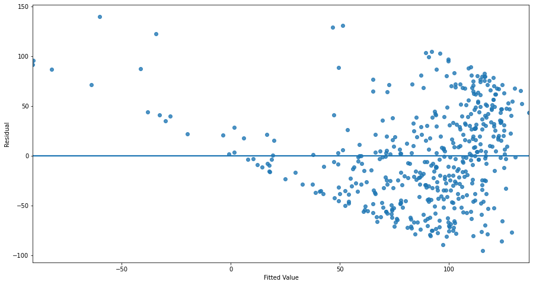

```python
plt.figure(figsize=(15, 8))
sns.regplot(x=mlr.fittedvalues, y=mlr.resid, ci=None)
plt.ylabel('Residual')
plt.xlabel('Fitted Value')
plt.show()
```

It seems that the number of objects above the line is about the same as the number of objects under the line, but it is still vague to determine precisely. We could say that the linearity condition is somewhat satisfied.

#### 2. Constant Variance

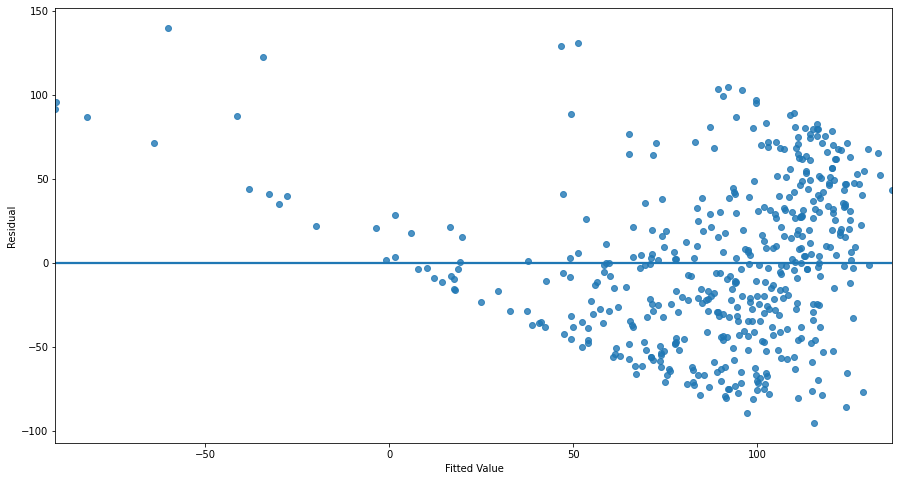

```python
plt.figure(figsize=(15, 8))
sns.regplot(x=mlr.fittedvalues, y=mlr.resid, ci=None)
plt.ylabel('Residual')
plt.xlabel('Fitted Value')
plt.show()
```

Since the spread in the plot above varies from left to right, we can say that the variance of the model is not constant.

#### 3. Normality

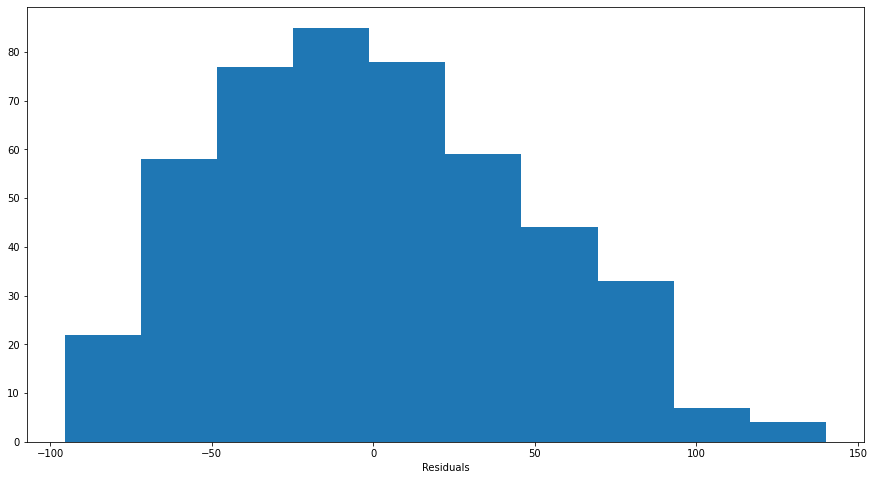

```python
plt.figure(figsize=(15, 8))
plt.hist(mlr.resid)
plt.xlabel('Residuals')
plt.show()
```

The histogram is skewed to the right, thus violating the normality condition.

#### 4. Residual Independence & Multicollinearity

All we can figure out was that "This is a random sample of song attributes for songs that have been on the Top 200 Weekly Global charts of Spotify in the years 2020 and 2021."

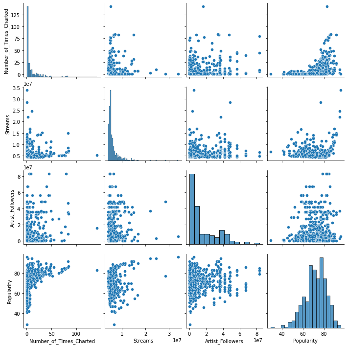

```python
sns.pairplot(df[['Number_of_Times_Charted', 'Streams', 'Artist_Followers', 'Popularity']])
plt.show()
```

```python
df[['Number_of_Times_Charted', 'Streams', 'Artist_Followers', 'Popularity']].corr()
```

|  | Number_of_Times_Charted | Streams | Artist_Followers | Popularity |
| --- | --- | --- | --- | --- |
| Number_of_Times_Charted | 1.000000 | -0.036494 | 0.080957 | 0.474509 |
| Streams | -0.036494 | 1.000000 | 0.072609 | 0.119730 |
| Artist_Followers | 0.080957 | 0.072609 | 1.000000 | 0.037811 |
| Popularity | 0.474509 | 0.119730 | 0.037811 | 1.000000 |

Although the correlation between 'Popularity' and 'Number_of_Times_Charted' is relatively higher than other correlations, it is still ambiguous to say that they are highly correlated. Thus, we might be good to keep all four explanatory variables in the model.

Considering that some of the linear regression conditions were not met, we should try log transforming the response variable.

```python
df['log_Highest_Charting_Position']=np.log(df['Highest_Charting_Position'])
df.head()
```

|  | Highest_Charting_Position | Number_of_Times_Charted | Week_of_Highest_Charting | Week_of_Highest_Charting_year | Week_of_Highest_Charting_month | Week_of_Highest_Charting_day | Song_Name | Streams | Artist | Artist_Followers | Song_ID | Release_Date | Release_Date_year | Release_Date_month | Release_Date_day | Weeks_Charted | Weeks_Charted_year | Weeks_Charted_month | Weeks_Charted_day | Popularity | Danceability | Energy | Loudness | Speechiness | Acousticness | Liveness | Tempo | Duration_ms | Valence | … |
| --- | --- | --- | --- | --- | --- | --- | --- | --- | --- | --- | --- | --- | --- | --- | --- | --- | --- | --- | --- | --- | --- | --- | --- | --- | --- | --- | --- | --- | --- | --- |
| 0 | 8 | 24 | 4/2/2021 | 2021 | 4 | 2 | Heartbreak Anniversary | 8832945 | Giveon | 1398563.0 | 3FAJ6O0NOHQV8Mc5Ri6ENp | 3/27/2020 | 2020.0 | 3 | 27.0 | 7/23/2021 | 2021 | 7 | 23 | 87.0 | 0.449 | 0.465 | -8.964 | 0.079 | 0.524 | 0.303 | 89.087 | 198371.0 | 0.543 | … |
| 1 | 92 | 2 | 5/15/2020 | 2020 | 5 | 15 | X (with KAROL G) | 5018592 | Jonas Brothers | 5436999.0 | 77fvnWALKJR0ws1VUx09CY | 5/15/2020 | 2020.0 | 5 | 15.0 | 5/22/2020 | 2020 | 5 | 22 | 70.0 | 0.715 | 0.827 | -5.090 | 0.062 | 0.049 | 0.321 | 117.977 | 185277.0 | 0.750 | … |
| 2 | 181 | 1 | 12/18/2020 | 2020 | 12 | 18 | Christmas Tree Farm | 6657404 | Taylor Swift | 42227614.0 | 2mvabkN1i2gLnGAPUVdwek | 12/6/2019 | 2019.0 | 12 | 6.0 | 12/18/2020 | 2020 | 12 | 18 | 52.0 | 0.598 | 0.680 | -4.505 | 0.033 | 0.060 | 0.324 | 134.002 | 228027.0 | 0.437 | … |
| 3 | 12 | 29 | 11/27/2020 | 2020 | 11 | 27 | TE MUDASTE | 5242347 | Bad Bunny | 36142273.0 | 5RubKOuDoPn5Kj5TLVxSxY | 11/27/2020 | 2020.0 | 11 | 27.0 | 6/11/2021 | 2021 | 6 | 11 | 82.0 | 0.811 | 0.637 | -4.835 | 0.059 | 0.234 | 0.118 | 92.025 | 130014.0 | 0.471 | … |
| 4 | 32 | 10 | 1/3/2020 | 2020 | 1 | 3 | Futsal Shuffle 2020 | 5386512 | Lil Uzi Vert | 11821805.0 | 2Ec33AVlkTTq8BHFgBTdQs | 12/12/2019 | 2019.0 | 12 | 12.0 | 2/28/2020 | 2020 | 2 | 28 | 67.0 | 0.881 | 0.457 | -8.191 | 0.156 | 0.033 | 0.231 | 136.970 | 198913.0 | 0.296 | … |

```python
# Log transformation
mlr2 = smf.ols('log_Highest_Charting_Position ~ Number_of_Times_Charted + Streams + Artist_Followers + Popularity', data = df).fit()
mlr2.summary()
```

OLS Regression Results

| Dep. Variable: | log_Highest_Charting_Position | R-squared: | 0.477 |
| --- | --- | --- | --- |
| Model: | OLS | Adj. R-squared: | 0.472 |
| Method: | Least Squares | F-statistic: | 105.3 |
| Date: | Thu, 09 Dec 2021 | Prob (F-statistic): | 1.15e-63 |
| Time: | 21:21:43 | Log-Likelihood: | -557.20 |
| No. Observations: | 467 | AIC: | 1124. |
| Df Residuals: | 462 | BIC: | 1145. |
| Df Model: | 4 |  |  |
| Covariance Type: | nonrobust |  |  |

|  | coef | std err | t | P>\|t\| | [0.025 | 0.975] |
| --- | --- | --- | --- | --- | --- | --- |
| Intercept | 6.0970 | 0.289 | 21.090 | 0.000 | 5.529 | 6.665 |
| Number_of_Times_Charted | -0.0335 | 0.003 | -13.128 | 0.000 | -0.038 | -0.028 |
| Streams | -1.236e-07 | 1.3e-08 | -9.525 | 0.000 | -1.49e-07 | -9.81e-08 |
| Artist_Followers | -1.293e-08 | 2.14e-09 | -6.044 | 0.000 | -1.71e-08 | -8.73e-09 |
| Popularity | -0.0094 | 0.004 | -2.264 | 0.024 | -0.018 | -0.001 |

| Omnibus: | 49.646 | Durbin-Watson: | 1.955 |
| --- | --- | --- | --- |
| Prob(Omnibus): | 0.000 | Jarque-Bera (JB): | 147.135 |
| Skew: | -0.482 | Prob(JB): | 1.12e-32 |
| Kurtosis: | 5.575 | Cond. No. | 1.88e+08 |

Notes:  
[1] Standard Errors assume that the covariance matrix of the errors is correctly specified.  
[2] The condition number is large, 1.88e+08. This might indicate that there are  
strong multicollinearity or other numerical problems.

#### Equation of the Transformed Model

$\log (\hat y_{Highest\ Charting\ Position}) = 6.0970 - 0.0335x_{Number\ of\ Times\ Charted} - 0.0000001236x_{Streams} - 0.00000001293x_{Artist\ Followers} - 0.0094x_{Popularity}$

### 4.2 Transformed Model Conditions Check

#### 1. Linearity

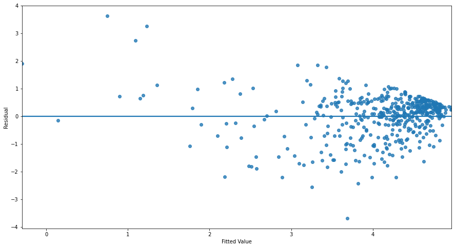

```python
plt.figure(figsize=(15, 8))
sns.regplot(x=mlr2.fittedvalues, y=mlr2.resid, ci=None)
plt.ylabel('Residual')
plt.xlabel('Fitted Value')
plt.show()
```

We can find out that some objects are highly concentrated above the line, thus the number of observations above the line is not going to be equal to the number of observations below the line. In other words, the linearity condition would be violated.

#### 2. Constant Variance

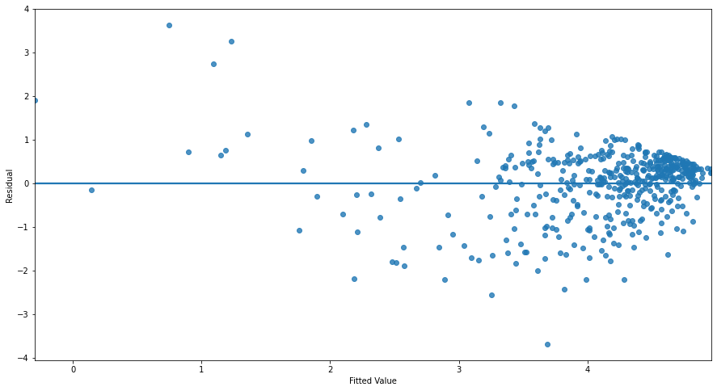

```python
plt.figure(figsize=(15, 8))
sns.regplot(x=mlr2.fittedvalues, y=mlr2.resid, ci=None)
plt.ylabel('Residual')
plt.xlabel('Fitted Value')
plt.show()
```

Similar to the plot of the original model, the spread varies from left to right. Therefore, the constant variance condition is also not met.

#### 3. Normality

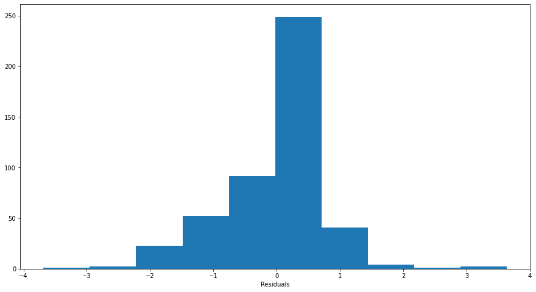

```python
plt.figure(figsize=(15, 8))
plt.hist(mlr2.resid)
plt.xlabel('Residuals')
plt.show()
```

The histogram above seems to be skewed to the left. Thus, the normality condition is not met as well.

#### 4. Residual Independence & Multicollinearity

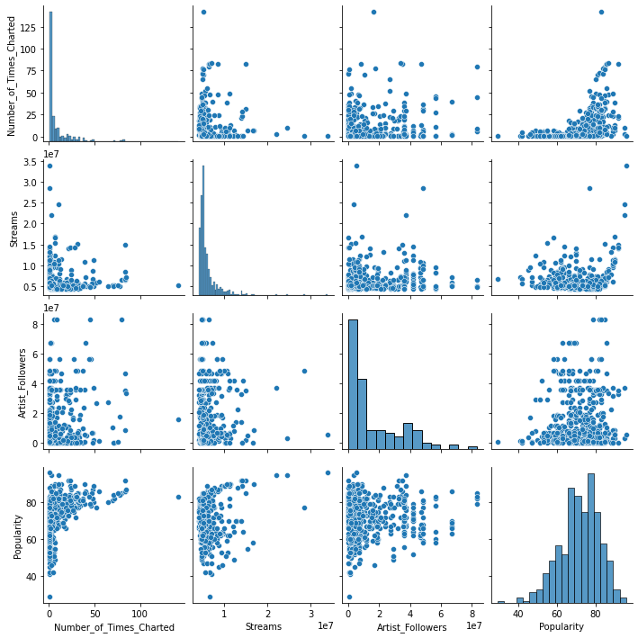

```python
sns.pairplot(df[['Number_of_Times_Charted', 'Streams', 'Artist_Followers', 'Popularity']])
plt.show()
```

```python
df[['Number_of_Times_Charted', 'Streams', 'Artist_Followers', 'Popularity']].corr()
```

|  | Number_of_Times_Charted | Streams | Artist_Followers | Popularity |
| --- | --- | --- | --- | --- |
| Number_of_Times_Charted | 1.000000 | -0.036494 | 0.080957 | 0.474509 |
| Streams | -0.036494 | 1.000000 | 0.072609 | 0.119730 |
| Artist_Followers | 0.080957 | 0.072609 | 1.000000 | 0.037811 |
| Popularity | 0.474509 | 0.119730 | 0.037811 | 1.000000 |

The residual independence and multicollinearity conditions are going to be the same as the original model's.

Since the conditions of the original model were not satisfied, we would expect the log transformation of the response variable would help fix the violation problem. However, the linear regression conditions were still not met even after the log transformation.

### Variability Explained by the Model

```python
print("R-squared Value of the Original Model: %s"%(mlr.rsquared))
print("R-squared Value of the Transformed Model: %s"%(mlr2.rsquared))
```

```
R-squared Value of the Original Model: 0.35823288513223694
R-squared Value of the Transformed Model: 0.47679605972515504
```

We can see that the $R^2$ value of the log-transformed model is larger than the original model. As a result, the log transformation was somewhat effective of explaining more variability of the response variable.

### Prediction

```python
# Prediction with the linear regression model

log_predict = mlr2.predict(exog=dict(Number_of_Times_Charted=30, Streams=500000, Artist_Followers=32000, Popularity=52))
log_predict
```

```
0    4.542859
dtype: float64
```

```python
np.exp(log_predict)
```

```
0    93.959014
dtype: float64
```

If an artist has 32000 followers and a song with popularity score of 52 that was charted 30 times and streamed 500000, we would expect the log of the song's highest charting position to be 4.54 on average. When converting this result, it is equivalent that the song's highest charting position would be 93.96th in the top 200 chart on average.

### Inference for Population Slopes

#### Hypothesis Test

- $H_0: \beta_{Number\ of\ Times\ Charted} = \beta_{Streams} = \beta_{Artist\ Followers} = \beta_{Popularity} = 0$
- $H_A$: At least one of the slopes is not zero.

```python
mlr2.summary()
```

OLS Regression Results

| Dep. Variable: | log_Highest_Charting_Position | R-squared: | 0.477 |
| --- | --- | --- | --- |
| Model: | OLS | Adj. R-squared: | 0.472 |
| Method: | Least Squares | F-statistic: | 105.3 |
| Date: | Thu, 09 Dec 2021 | Prob (F-statistic): | 1.15e-63 |
| Time: | 21:21:46 | Log-Likelihood: | -557.20 |
| No. Observations: | 467 | AIC: | 1124. |
| Df Residuals: | 462 | BIC: | 1145. |
| Df Model: | 4 |  |  |
| Covariance Type: | nonrobust |  |  |

|  | coef | std err | t | P>\|t\| | [0.025 | 0.975] |
| --- | --- | --- | --- | --- | --- | --- |
| Intercept | 6.0970 | 0.289 | 21.090 | 0.000 | 5.529 | 6.665 |
| Number_of_Times_Charted | -0.0335 | 0.003 | -13.128 | 0.000 | -0.038 | -0.028 |
| Streams | -1.236e-07 | 1.3e-08 | -9.525 | 0.000 | -1.49e-07 | -9.81e-08 |
| Artist_Followers | -1.293e-08 | 2.14e-09 | -6.044 | 0.000 | -1.71e-08 | -8.73e-09 |
| Popularity | -0.0094 | 0.004 | -2.264 | 0.024 | -0.018 | -0.001 |

| Omnibus: | 49.646 | Durbin-Watson: | 1.955 |
| --- | --- | --- | --- |
| Prob(Omnibus): | 0.000 | Jarque-Bera (JB): | 147.135 |
| Skew: | -0.482 | Prob(JB): | 1.12e-32 |
| Kurtosis: | 5.575 | Cond. No. | 1.88e+08 |

Notes:  
[1] Standard Errors assume that the covariance matrix of the errors is correctly specified.  
[2] The condition number is large, 1.88e+08. This might indicate that there are  
strong multicollinearity or other numerical problems.

We can find the test statistic and p-value for this hypothesis test in the summary.

- **test statistic (F-statistic)** = 105.3
- **p-value (Prob (F-statistic))** = 1.15e-63

Since the p-value for the F-test is 1.15e-63, which is significantly smaller than the significance level, $\alpha = 0.05$, we reject the null and conclude that at least one of the slopes in the corresponding population model is not zero.

To sum up, we found out that there would be at least some linear relationship between a song's highest charting position and its song's artist features. However, we should be careful of interpreting the conclusion that we get from here since both of our models failed of satisfying the linear regression conditions.

## 5. Logistic Regression

### Research Question

Would there be any noticeable association between 'hip hop' or 'rap' songs and their music components? Plus, can we accurately predict whether a song is hip hop or not based on its music components?

```python
df['Genre_1'].unique()
```

```
array(['pop', 'boy band', 'latin', 'melodic rap', 'k-pop',
       'colombian pop', 'hip hop', 'trap chileno', 'deep german hip hop',
       'comic', 'conscious hip hop', 'indie rock italiano', 'atl hip hop',
       'canadian pop', 'trap latino', 'sertanejo', 'italian hip hop',
       'modern alternative rock', 'german hip hop', 'edm', 'dance pop',
       'francoton', 'acoustic pop', 'brooklyn drill', 'alternative r&b',
       'puerto rican pop', 'latin pop', 'east coast hip hop',
       'houston rap', 'uk hip hop', 'trap queen', 'australian pop',
       'sad rap', 'trap argentino', 'chicago rap', 'adult standards',
       'australian rock', 'london rap', 'canadian contemporary r&b',
       'lgbtq+ hip hop', 'german cloud rap', 'dfw rap',
       'north carolina hip hop', 'alt z', 'nyc rap', 'brostep',
       'dominican pop', 'french hip hop', 'classic uk pop',
       'memphis hip hop', 'rap', 'neo mellow', 'australian hip hop',
       'canadian hip hop', 'modern rock', 'cali rap', 'pop soul',
       'detroit hip hop', 'forro', 'r&b brasileiro', 'australian dance',
       'melodic metalcore', 'mariachi', 'electropop', 'dance rock',
       'albanian hip hop', 'eurovision', 'florida rap', 'meme rap',
       'art pop', 'chicago soul', 'pop rap', 'contemporary country',
       'belgian hip hop', 'argentine hip hop', 'british soul',
       'sertanejo pop', 'emo rap', 'viral rap', 'funk carioca',
       'gauze pop', 'reggaeton', 'a cappella', 'celtic', 'electro house',
       'album rock', 'ohio hip hop', 'italian adult pop', 'bedroom pop',
       'garage rock', 'musical advocacy', 'brega funk', 'afroswing',
       'afrofuturism', 'german drill', 'k-pop girl group', 'new wave pop',
       'big room', 'icelandic pop', 'australian psych'], dtype=object)
```

We can see from the result above that there are too many genres in the dataset. Since 'hip hop' and 'rap' can be considered as a same genre, we are going to group two genres into one genre, 'hiphop'.

```python
t = 'hip hop'
t[-3:]
```

```
'hop'
```

```python
df['Genre_1'].iloc[3][-3:]
```

```
'tin'
```

```python
df['y_hiphop'] = ""

for i in range(len(df)):
    # If a genre's last three letters are either 'hop' (X + hip hop) or 'rap' (X + rap), label it as '1'
    if (df['Genre_1'].iloc[i][-3:] == 'hop')|(df['Genre_1'].iloc[i][-3:] == 'rap'):
        df['y_hiphop'].iloc[i] = 1
    # If not, label as '0'
    else:
        df['y_hiphop'].iloc[i] = 0
```

```python
df
```

|  | Highest_Charting_Position | Number_of_Times_Charted | Week_of_Highest_Charting | Week_of_Highest_Charting_year | Week_of_Highest_Charting_month | Week_of_Highest_Charting_day | Song_Name | Streams | Artist | Artist_Followers | Song_ID | Release_Date | Release_Date_year | Release_Date_month | Release_Date_day | Weeks_Charted | Weeks_Charted_year | Weeks_Charted_month | Weeks_Charted_day | Popularity | Danceability | Energy | Loudness | Speechiness | Acousticness | Liveness | Tempo | Duration_ms | Valence | … |
| --- | --- | --- | --- | --- | --- | --- | --- | --- | --- | --- | --- | --- | --- | --- | --- | --- | --- | --- | --- | --- | --- | --- | --- | --- | --- | --- | --- | --- | --- | --- |
| 0 | 8 | 24 | 4/2/2021 | 2021 | 4 | 2 | Heartbreak Anniversary | 8832945 | Giveon | 1398563.0 | 3FAJ6O0NOHQV8Mc5Ri6ENp | 3/27/2020 | 2020.0 | 3 | 27.0 | 7/23/2021 | 2021 | 7 | 23 | 87.0 | 0.449 | 0.465 | -8.964 | 0.079 | 0.524 | 0.303 | 89.087 | 198371.0 | 0.543 | … |
| 1 | 92 | 2 | 5/15/2020 | 2020 | 5 | 15 | X (with KAROL G) | 5018592 | Jonas Brothers | 5436999.0 | 77fvnWALKJR0ws1VUx09CY | 5/15/2020 | 2020.0 | 5 | 15.0 | 5/22/2020 | 2020 | 5 | 22 | 70.0 | 0.715 | 0.827 | -5.090 | 0.062 | 0.049 | 0.321 | 117.977 | 185277.0 | 0.750 | … |
| 2 | 181 | 1 | 12/18/2020 | 2020 | 12 | 18 | Christmas Tree Farm | 6657404 | Taylor Swift | 42227614.0 | 2mvabkN1i2gLnGAPUVdwek | 12/6/2019 | 2019.0 | 12 | 6.0 | 12/18/2020 | 2020 | 12 | 18 | 52.0 | 0.598 | 0.680 | -4.505 | 0.033 | 0.060 | 0.324 | 134.002 | 228027.0 | 0.437 | … |
| 3 | 12 | 29 | 11/27/2020 | 2020 | 11 | 27 | TE MUDASTE | 5242347 | Bad Bunny | 36142273.0 | 5RubKOuDoPn5Kj5TLVxSxY | 11/27/2020 | 2020.0 | 11 | 27.0 | 6/11/2021 | 2021 | 6 | 11 | 82.0 | 0.811 | 0.637 | -4.835 | 0.059 | 0.234 | 0.118 | 92.025 | 130014.0 | 0.471 | … |
| 4 | 32 | 10 | 1/3/2020 | 2020 | 1 | 3 | Futsal Shuffle 2020 | 5386512 | Lil Uzi Vert | 11821805.0 | 2Ec33AVlkTTq8BHFgBTdQs | 12/12/2019 | 2019.0 | 12 | 12.0 | 2/28/2020 | 2020 | 2 | 28 | 67.0 | 0.881 | 0.457 | -8.191 | 0.156 | 0.033 | 0.231 | 136.970 | 198913.0 | 0.296 | … |
| ... | ... | ... | ... | ... | ... | ... | ... | ... | ... | ... | ... | ... | ... | ... | ... | ... | ... | ... | ... | ... | ... | ... | ... | ... | ... | ... | ... | ... | ... | … |
| 494 | 4 | 76 | 6/19/2020 | 2020 | 6 | 19 | death bed (coffee for your head) | 5238547 | Powfu, beabadoobee | 924083.0 | 7eJMfftS33KTjuF7lTsMCx | 2/8/2020 | 2020.0 | 2 | 8.0 | 7/23/2021 | 2021 | 7 | 23 | 85.0 | 0.726 | 0.431 | -8.765 | 0.135 | 0.731 | 0.696 | 144.026 | 173333.0 | 0.348 | … |
| 495 | 30 | 9 | 4/10/2020 | 2020 | 4 | 10 | Level of Concern | 4252898 | Twenty One Pilots | 20829526.0 | 6xZ4Q2k2ompmDppyeESIY8 | 4/9/2020 | 2020.0 | 4 | 9.0 | 6/5/2020 | 2020 | 6 | 5 | 72.0 | 0.754 | 0.583 | -7.340 | 0.043 | 0.320 | 0.144 | 122.012 | 220051.0 | 0.770 | … |
| 496 | 29 | 15 | 1/24/2020 | 2020 | 1 | 24 | What If I Told You That I Love You | 5234645 | Ali Gatie | 1758300.0 | 6USdi8uX5GNAPYziFhisHb | 3/26/2021 | 2021.0 | 3 | 26.0 | 5/1/2020 | 2020 | 5 | 1 | 69.0 | 0.596 | 0.366 | -11.144 | 0.115 | 0.630 | 0.055 | 84.394 | 193668.0 | 0.229 | … |
| 498 | 6 | 7 | 12/18/2020 | 2020 | 12 | 18 | It's Beginning to Look a Lot like Christmas | 15424001 | Michael Bublé | 4702232.0 | 5a1iz510sv2W9Dt1MvFd5R | 11/9/2012 | 2012.0 | 11 | 9.0 | 12/25/2020 | 2020 | 12 | 25 | 55.0 | 0.339 | 0.214 | -11.714 | 0.038 | 0.908 | 0.341 | 94.775 | 206640.0 | 0.363 | … |
| 499 | 124 | 3 | 11/6/2020 | 2020 | 11 | 6 | Sweet Melody | 5201322 | Little Mix | 9398941.0 | 76Tuo484SLohJakHLnGI3B | 11/6/2020 | 2020.0 | 11 | 6.0 | 11/13/2020 | 2020 | 11 | 13 | 73.0 | 0.448 | 0.824 | -4.249 | 0.057 | 0.074 | 0.113 | 119.965 | 213693.0 | 0.419 | … |

467 rows × 34 columns

```python
df['y_hiphop'] = pd.to_numeric(df['y_hiphop'])
```

We run the code above(code #45) in order to run the logistic model below without getting an error message (code #47).

#### Error Message

ValueError: endog has evaluated to an array with multiple columns that has shape (373, 2). This occurs when the variable converted to endog is non-numeric (e.g., bool or str)

```python
# Spliting the dataset into training & Test

from sklearn.model_selection import train_test_split

df_train, df_test = train_test_split(df, test_size = 0.20, random_state = 100)
```

We are splitting the dataset into 'training' and 'test' dataset, and the proportion of these two datasets would be 8:2.

```python
log_mod = smf.logit('y_hiphop ~ Danceability + Energy + Loudness + Speechiness + Acousticness + Liveness + Tempo + Duration_ms + Valence', data = df_train).fit()
log_mod.summary()
```

```
Optimization terminated successfully.
         Current function value: 0.475105
         Iterations 6
```

Logit Regression Results

| Dep. Variable: | y_hiphop | No. Observations: | 373 |
| --- | --- | --- | --- |
| Model: | Logit | Df Residuals: | 363 |
| Method: | MLE | Df Model: | 9 |
| Date: | Thu, 09 Dec 2021 | Pseudo R-squ.: | 0.2362 |
| Time: | 21:21:49 | Log-Likelihood: | -177.21 |
| converged: | True | LL-Null: | -232.01 |
| Covariance Type: | nonrobust | LLR p-value: | 1.782e-19 |

|  | coef | std err | z | P>\|z\| | [0.025 | 0.975] |
| --- | --- | --- | --- | --- | --- | --- |
| Intercept | -4.1282 | 1.932 | -2.137 | 0.033 | -7.915 | -0.341 |
| Danceability | 4.0619 | 1.210 | 3.356 | 0.001 | 1.690 | 6.434 |
| Energy | -1.1354 | 1.412 | -0.804 | 0.421 | -3.902 | 1.631 |
| Loudness | -0.0886 | 0.091 | -0.968 | 0.333 | -0.268 | 0.091 |
| Speechiness | 7.8416 | 1.285 | 6.104 | 0.000 | 5.324 | 10.360 |
| Acousticness | -1.2134 | 0.729 | -1.664 | 0.096 | -2.643 | 0.216 |
| Liveness | 2.3234 | 1.002 | 2.318 | 0.020 | 0.359 | 4.288 |
| Tempo | 0.0044 | 0.005 | 0.929 | 0.353 | -0.005 | 0.014 |
| Duration_ms | 1.012e-06 | 2.84e-06 | 0.356 | 0.722 | -4.55e-06 | 6.58e-06 |
| Valence | -2.7224 | 0.705 | -3.861 | 0.000 | -4.104 | -1.340 |

### Backward Elimination (AIC)

```python
full_mod = smf.logit('y_hiphop ~ Danceability + Energy + Loudness + Speechiness + Acousticness + Liveness + Tempo + Duration_ms + Valence', data = df_train).fit()
full_mod.aic
```

```
Optimization terminated successfully.
         Current function value: 0.475105
         Iterations 6
```

```
374.4283124779297
```

Instead of running multiple test models one at a time, we made a for loop to iterate faster.

```python
pred_list = ['Danceability', 'Energy', 'Loudness', 'Speechiness', 'Acousticness', 'Liveness', 'Tempo', 'Duration_ms', 'Valence']
elim_list = []
full_mod = smf.logit('y_hiphop ~ Danceability + Energy + Loudness + Speechiness + Acousticness + Liveness + Tempo + Duration_ms + Valence', data = df_train).fit()

for pred in pred_list:
    print("Model Without %s"%(pred))

    # Every time the loop iterates, the test mod is going to run the logistic regression function dropping one predictor from 'predictor list'
    test_mod = smf.logit('y_hiphop ~ Danceability + Energy + Loudness + Speechiness + Acousticness + Liveness + Tempo + Duration_ms + Valence - %s'%(pred), data = df_train).fit()

    print("AIC Score of Full Model: %s"%(full_mod.aic))
    print("AIC Score of Test Model: %s"%(test_mod.aic))

    if full_mod.aic < test_mod.aic:
        print("Full Model is Better")
    else:
        print("Test Model is Better")

        # Append the test mod's AIC score and its model's dropped predictor
        elim_list.append(str(test_mod.aic) + "Without %s"%(pred))
    print('-----------------------------------')

# If there is at least one element in the list, pick the element with the minimum value
if len(elim_list) != 0:
    print("Final Model Selection")
    print(min(elim_list))

# When there is no value in the elimination list (Meaning that none of the test models have lower AIC scores than the full model's AIC score)
else:
    print("Full Model is the Best, Stop Backward Iteration!")
```

```
Optimization terminated successfully.
         Current function value: 0.475105
         Iterations 6
Model Without Danceability
Optimization terminated successfully.
         Current function value: 0.491207
         Iterations 6
AIC Score of Full Model: 374.4283124779297
AIC Score of Test Model: 384.44051855496014
Full Model is Better
-----------------------------------
Model Without Energy
Optimization terminated successfully.
         Current function value: 0.475976
         Iterations 6
AIC Score of Full Model: 374.4283124779297
AIC Score of Test Model: 373.07779302593826
Test Model is Better
-----------------------------------
Model Without Loudness
Optimization terminated successfully.
         Current function value: 0.476357
         Iterations 6
AIC Score of Full Model: 374.4283124779297
AIC Score of Test Model: 373.36251715858606
Test Model is Better
-----------------------------------
Model Without Speechiness
Optimization terminated successfully.
         Current function value: 0.535225
         Iterations 6
AIC Score of Full Model: 374.4283124779297
AIC Score of Test Model: 417.27782600732473
Full Model is Better
-----------------------------------
Model Without Acousticness
Optimization terminated successfully.
         Current function value: 0.478898
         Iterations 6
AIC Score of Full Model: 374.4283124779297
```

[output cut: 22 more lines]

```
         Iterations 6
AIC Score of Full Model: 374.4283124779297
AIC Score of Test Model: 372.5537424107182
Test Model is Better
-----------------------------------
Model Without Valence
Optimization terminated successfully.
         Current function value: 0.496660
         Iterations 6
AIC Score of Full Model: 374.4283124779297
AIC Score of Test Model: 388.50820752359573
Full Model is Better
-----------------------------------
Final Model Selection
372.5537424107182Without Duration_ms
```

The loop suggests to drop **'Duration_ms'** after the first iteration.

```python
# Second Backward Iteration - Without 'Duration_ms' predictor
pred_list = ['Danceability', 'Energy', 'Loudness', 'Speechiness', 'Acousticness', 'Liveness', 'Tempo', 'Valence']
elim_list = []

# Model without 'Duration_ms'
current_mod = smf.logit('y_hiphop ~ Danceability + Energy + Loudness + Speechiness + Acousticness + Liveness + Tempo + Valence', data = df_train).fit()

for pred in pred_list:
    print("Model Without %s"%(pred))
    test_mod = smf.logit('y_hiphop ~ Danceability + Energy + Loudness + Speechiness + Acousticness + Liveness + Tempo + Valence - %s'%(pred), data = df_train).fit()
    print("AIC Score of Current Model: %s"%(current_mod.aic))
    print("AIC Score of Test Model: %s"%(test_mod.aic))
    if current_mod.aic < test_mod.aic:
        print("Current Model is Better")
    else:
        print("Test Model is Better")
        elim_list.append(str(test_mod.aic) + "Without %s"%(pred))
    print('-----------------------------------')
if len(elim_list) != 0:
    print("Final Model Selection")
    print(min(elim_list))
else:
    print("Current Model is the Best, Stop Backward Iteration!")
```

```
Optimization terminated successfully.
         Current function value: 0.475273
         Iterations 6
Model Without Danceability
Optimization terminated successfully.
         Current function value: 0.491238
         Iterations 6
AIC Score of Current Model: 372.5537424107182
AIC Score of Test Model: 382.46351449178536
Current Model is Better
-----------------------------------
Model Without Energy
Optimization terminated successfully.
         Current function value: 0.476144
         Iterations 6
AIC Score of Current Model: 372.5537424107182
AIC Score of Test Model: 371.20315080335877
Test Model is Better
-----------------------------------
Model Without Loudness
Optimization terminated successfully.
         Current function value: 0.476470
         Iterations 6
AIC Score of Current Model: 372.5537424107182
AIC Score of Test Model: 371.44675712106886
Test Model is Better
-----------------------------------
Model Without Speechiness
Optimization terminated successfully.
         Current function value: 0.535433
         Iterations 6
AIC Score of Current Model: 372.5537424107182
AIC Score of Test Model: 415.4331012572423
Current Model is Better
-----------------------------------
Model Without Acousticness
Optimization terminated successfully.
         Current function value: 0.478986
         Iterations 6
AIC Score of Current Model: 372.5537424107182
```

[output cut: 14 more lines]

```
         Iterations 6
AIC Score of Current Model: 372.5537424107182
AIC Score of Test Model: 371.3976452449525
Test Model is Better
-----------------------------------
Model Without Valence
Optimization terminated successfully.
         Current function value: 0.497301
         Iterations 6
AIC Score of Current Model: 372.5537424107182
AIC Score of Test Model: 386.98687808156046
Current Model is Better
-----------------------------------
Final Model Selection
371.20315080335877Without Energy
```

After the second iteration, the model without **'Energy'** has the lowest AIC scores. Thus, we drop **'Energy'** and continue the backward elimination iteration.

```python
# Third Backward Iteration - Without 'Duration_ms' and 'Energy'

pred_list = ['Danceability', 'Loudness', 'Speechiness', 'Acousticness', 'Liveness', 'Tempo', 'Valence']
elim_list = []

# Model without 'Duration_ms' and 'Energy'
current_mod = smf.logit('y_hiphop ~ Danceability + Loudness + Speechiness + Acousticness + Liveness + Tempo + Valence', data = df_train).fit()

for pred in pred_list:
    print("Model Without %s"%(pred))
    test_mod = smf.logit('y_hiphop ~ Danceability + Loudness + Speechiness + Acousticness + Liveness + Tempo + Valence - %s'%(pred), data = df_train).fit()
    print("AIC Score of Current Model: %s"%(current_mod.aic))
    print("AIC Score of Test Model: %s"%(test_mod.aic))
    if current_mod.aic < test_mod.aic:
        print("Current Model is Better")
    else:
        print("Test Model is Better")
        elim_list.append(str(test_mod.aic) + "Without %s"%(pred))
    print('-----------------------------------')
if len(elim_list) != 0:
    print("Final Model Selection")
    print(min(elim_list))
else:
    print("Current Model is the Best, Stop Backward Iteration!")
```

```
Optimization terminated successfully.
         Current function value: 0.476144
         Iterations 6
Model Without Danceability
Optimization terminated successfully.
         Current function value: 0.494305
         Iterations 6
AIC Score of Current Model: 371.20315080335877
AIC Score of Test Model: 382.7513674714583
Current Model is Better
-----------------------------------
Model Without Loudness
Optimization terminated successfully.
         Current function value: 0.480844
         Iterations 6
AIC Score of Current Model: 371.20315080335877
AIC Score of Test Model: 372.70941244076687
Current Model is Better
-----------------------------------
Model Without Speechiness
Optimization terminated successfully.
         Current function value: 0.535555
         Iterations 6
AIC Score of Current Model: 371.20315080335877
AIC Score of Test Model: 413.5239073324336
Current Model is Better
-----------------------------------
Model Without Acousticness
Optimization terminated successfully.
         Current function value: 0.479174
         Iterations 6
AIC Score of Current Model: 371.20315080335877
AIC Score of Test Model: 371.46414007329577
Current Model is Better
-----------------------------------
Model Without Liveness
Optimization terminated successfully.
         Current function value: 0.483169
         Iterations 6
AIC Score of Current Model: 371.20315080335877
AIC Score of Test Model: 374.4441781165435
Current Model is Better
-----------------------------------
Model Without Tempo
Optimization terminated successfully.
         Current function value: 0.477334
         Iterations 6
AIC Score of Current Model: 371.20315080335877
AIC Score of Test Model: 370.0911047914605
Test Model is Better
-----------------------------------
Model Without Valence
Optimization terminated successfully.
         Current function value: 0.501333
         Iterations 6
AIC Score of Current Model: 371.20315080335877
AIC Score of Test Model: 387.99445893465236
Current Model is Better
-----------------------------------
Final Model Selection
370.0911047914605Without Tempo
```

Even after the third iteration, there is a test model that has lower AIC score than the current model. This time, we drop **'Tempo'** and run the loop again.

```python
# Fourth Backward Iteration - Without 'Duration_ms', 'Energy', and 'Tempo'

pred_list = ['Danceability', 'Loudness', 'Speechiness', 'Acousticness', 'Liveness', 'Valence']
elim_list = []

# Model without 'Duration_ms', 'Energy', and 'Tempo'
current_mod = smf.logit('y_hiphop ~ Danceability + Loudness + Speechiness + Acousticness + Liveness + Valence', data = df_train).fit()

for pred in pred_list:
    print("Model Without %s"%(pred))
    test_mod = smf.logit('y_hiphop ~ Danceability + Loudness + Speechiness + Acousticness + Liveness + Valence - %s'%(pred), data = df_train).fit()
    print("AIC Score of Current Model: %s"%(current_mod.aic))
    print("AIC Score of Test Model: %s"%(test_mod.aic))
    if current_mod.aic < test_mod.aic:
        print("Current Model is Better")
    else:
        print("Test Model is Better")
        elim_list.append(str(test_mod.aic) + "Without %s"%(pred))
    print('-----------------------------------')
if len(elim_list) != 0:
    print("Final Model Selection")
    print(min(elim_list))
else:
    print("Current Model is the Best, Stop Backward Iteration!")
```

```
Optimization terminated successfully.
         Current function value: 0.477334
         Iterations 6
Model Without Danceability
Optimization terminated successfully.
         Current function value: 0.494711
         Iterations 6
AIC Score of Current Model: 370.0911047914605
AIC Score of Test Model: 381.0544096792821
Current Model is Better
-----------------------------------
Model Without Loudness
Optimization terminated successfully.
         Current function value: 0.481709
         Iterations 6
AIC Score of Current Model: 370.0911047914605
AIC Score of Test Model: 371.3549782018214
Current Model is Better
-----------------------------------
Model Without Speechiness
Optimization terminated successfully.
         Current function value: 0.542715
         Iterations 6
AIC Score of Current Model: 370.0911047914605
AIC Score of Test Model: 416.86536657393606
Current Model is Better
-----------------------------------
Model Without Acousticness
Optimization terminated successfully.
         Current function value: 0.480598
         Iterations 6
AIC Score of Current Model: 370.0911047914605
AIC Score of Test Model: 370.5262420868753
Current Model is Better
-----------------------------------
Model Without Liveness
Optimization terminated successfully.
         Current function value: 0.483851
         Iterations 6
AIC Score of Current Model: 370.0911047914605
AIC Score of Test Model: 372.9525205734517
Current Model is Better
-----------------------------------
Model Without Valence
Optimization terminated successfully.
         Current function value: 0.502465
         Iterations 6
AIC Score of Current Model: 370.0911047914605
AIC Score of Test Model: 386.8385589679512
Current Model is Better
-----------------------------------
Current Model is the Best, Stop Backward Iteration!
```

After the fourth iteration, we got a message that the current model is the best, indicating that none of the test models in the fourth iteration had AIC scores lower than the current model. Consequently, we stop the iteration and choose the current model as our final (most parsimonious) model!

#### Final Model

```python
final_mod = smf.logit('y_hiphop ~ Danceability + Loudness + Speechiness + Acousticness + Liveness + Valence', data = df_train).fit()
final_mod.summary()
```

```
Optimization terminated successfully.
         Current function value: 0.477334
         Iterations 6
```

Logit Regression Results

| Dep. Variable: | y_hiphop | No. Observations: | 373 |
| --- | --- | --- | --- |
| Model: | Logit | Df Residuals: | 366 |
| Method: | MLE | Df Model: | 6 |
| Date: | Thu, 09 Dec 2021 | Pseudo R-squ.: | 0.2326 |
| Time: | 21:21:50 | Log-Likelihood: | -178.05 |
| converged: | True | LL-Null: | -232.01 |
| Covariance Type: | nonrobust | LLR p-value: | 5.537e-21 |

|  | coef | std err | z | P>\|z\| | [0.025 | 0.975] |
| --- | --- | --- | --- | --- | --- | --- |
| Intercept | -4.3158 | 0.968 | -4.457 | 0.000 | -6.214 | -2.418 |
| Danceability | 4.0778 | 1.172 | 3.480 | 0.001 | 1.781 | 6.375 |
| Loudness | -0.1279 | 0.071 | -1.811 | 0.070 | -0.266 | 0.010 |
| Speechiness | 7.9076 | 1.253 | 6.309 | 0.000 | 5.451 | 10.364 |
| Acousticness | -1.0820 | 0.702 | -1.542 | 0.123 | -2.458 | 0.294 |
| Liveness | 2.1592 | 0.974 | 2.216 | 0.027 | 0.250 | 4.069 |
| Valence | -2.8531 | 0.688 | -4.145 | 0.000 | -4.202 | -1.504 |

```python
final_mod.aic
```

```
370.0911047914605
```

### Hypothesis Test (Reduced (Final) vs Full)

- $H_0$: The reduced model is better than the full model. ($\beta_{Duration\ ms} = \beta_{Energy} = \beta_{Tempo} = 0$)
- $H_A$: The reduced model is incorrect because at least one of the slopes that we dropped is not zero.

### Test Statistic & p-value

```python
# Log-Likelihood Ratio Test
test_stat = -2*(final_mod.llf - full_mod.llf)
test_stat
```

```
1.6627923135308151
```

```python
from scipy.stats import chi2

p_val = 1 - chi2.cdf(test_stat, df = 3)
p_val
```

```
0.6452373459230079
```

Since the p-value is relatively larger than the typical significance level $\alpha = 0.05$, we fail to reject the null and conclude that the reduced model is better than the full model.

#### Equation of the Final Model

$\log(\frac{\hat p_{Hiphop}}{1 - \hat p_{Hiphop}}) = -4.3158 + 4.0778x_{Danceability} - 0.1279x_{Loudness} + 7.9076x_{Speechiness} - 1.0820x_{Acousticness} + 2.1592x_{Liveness} - 2.8531x_{Valence}$

Although the final model has the lowest AIC score compared to other test models, we can see from the summary above that there are still some explanatory variables with high p-values (**'Loudness'**, **'Acousticness'**). This might indicate that the final model may not be the most parsimonious model.

We may try dropping these two variables, fitting a new reduced model and comparing its AIC score with the final model.

```python
new_red = smf.logit('y_hiphop ~ Danceability + Speechiness + Liveness + Valence', data = df_train).fit()
new_red.summary()
```

```
Optimization terminated successfully.
         Current function value: 0.482719
         Iterations 6
```

Logit Regression Results

| Dep. Variable: | y_hiphop | No. Observations: | 373 |
| --- | --- | --- | --- |
| Model: | Logit | Df Residuals: | 368 |
| Method: | MLE | Df Model: | 4 |
| Date: | Thu, 09 Dec 2021 | Pseudo R-squ.: | 0.2239 |
| Time: | 21:21:50 | Log-Likelihood: | -180.05 |
| converged: | True | LL-Null: | -232.01 |
| Covariance Type: | nonrobust | LLR p-value: | 1.446e-21 |

|  | coef | std err | z | P>\|z\| | [0.025 | 0.975] |
| --- | --- | --- | --- | --- | --- | --- |
| Intercept | -3.8928 | 0.776 | -5.018 | 0.000 | -5.413 | -2.372 |
| Danceability | 4.4344 | 1.130 | 3.924 | 0.000 | 2.219 | 6.650 |
| Speechiness | 8.2737 | 1.243 | 6.657 | 0.000 | 5.838 | 10.710 |
| Liveness | 2.0072 | 0.967 | 2.075 | 0.038 | 0.112 | 3.903 |
| Valence | -3.1136 | 0.677 | -4.600 | 0.000 | -4.440 | -1.787 |

#### Equation of the New Reduced Model

$\log(\frac{\hat p_{Hiphop}}{1 - \hat p_{Hiphop}}) = -3.8928 + 4.4344x_{Danceability} + 8.2737x_{Speechiness} + 2.0072x_{Liveness} - 3.1136x_{Valence}$

```python
print(new_red.aic, final_mod.aic)
```

```
370.1082644244128 370.0911047914605
```

Although all predictors in the new reduced model are statistically significant (p-values lower than $\alpha = 0.05$), the AIC score is slightly higher than the final model.

### Hypothesis Test (New Reduced (new_red) vs Final (final_mod))

- $H_0$: The new reduced model is better than the final model. ($\beta_{Loudness} = \beta_{Acousticness} = 0$)
- $H_A$: The new reduced model is incorrect because at least one of the slopes ($\beta$'s) is not equal to 0.

### Test Statistic & p-value

```python
print(new_red.llf, final_mod.llf)
```

```
-180.0541322122064 -178.04555239573025
```

```python
test_stat = -2*(new_red.llf - final_mod.llf)
test_stat
```

```
4.017159632952314
```

```python
p_val = 1 - chi2.cdf(test_stat, df = 2)
p_val
```

```
0.13417909836324204
```

Similarly, we get a relatively high p-value that is larger than the significance level $\alpha = 0.05$. Therefore, we would fail to reject the null and conclude that the new reduced model is better.

However, even if we have a result that the new reduced model is better, its AIC score is surely higher than the final model's AIC score. Thus, we cannot say that the new reduced model is the most parsimonious model.

### ROC/AUC of the Two Models

#### New Reduced Model

We will create ROC and AUC with the new reduced model.

```python
from sklearn.metrics import roc_curve, roc_auc_score

new_red = smf.logit('y_hiphop ~ Danceability + Speechiness + Liveness + Valence', data = df_train).fit()

phat_test = new_red.predict(exog=df_test)
phat_test.head(10)
```

```
Optimization terminated successfully.
         Current function value: 0.482719
         Iterations 6
```

```
248    0.400130
292    0.129056
494    0.680699
457    0.337906
261    0.140908
98     0.332769
232    0.084623
75     0.284623
250    0.097726
354    0.142163
dtype: float64
```

```python
df_test['phat_test']=phat_test
df_test
```

|  | Highest_Charting_Position | Number_of_Times_Charted | Week_of_Highest_Charting | Week_of_Highest_Charting_year | Week_of_Highest_Charting_month | Week_of_Highest_Charting_day | Song_Name | Streams | Artist | Artist_Followers | Song_ID | Release_Date | Release_Date_year | Release_Date_month | Release_Date_day | Weeks_Charted | Weeks_Charted_year | Weeks_Charted_month | Weeks_Charted_day | Popularity | Danceability | Energy | Loudness | Speechiness | Acousticness | Liveness | Tempo | Duration_ms | Valence | … |
| --- | --- | --- | --- | --- | --- | --- | --- | --- | --- | --- | --- | --- | --- | --- | --- | --- | --- | --- | --- | --- | --- | --- | --- | --- | --- | --- | --- | --- | --- | --- |
| 248 | 53 | 1 | 5/1/2020 | 2020 | 5 | 1 | Desires (with Future) | 9628215 | Drake | 56327031.0 | 7eYAHC0RbBF9eaqWzT34Aq | 5/1/2020 | 2020.0 | 5 | 1.0 | 5/1/2020 | 2020 | 5 | 1 | 64.0 | 0.812 | 0.506 | -7.706 | 0.116 | 0.281 | 0.325 | 145.074 | 237946.0 | 0.554 | … |
| 292 | 9 | 28 | 6/12/2020 | 2020 | 6 | 12 | Party Girl | 4878286 | StaySolidRocky | 150587.0 | 5RqR4ZCCKJDcBLIn4sih9l | 4/21/2020 | 2020.0 | 4 | 21.0 | 11/20/2020 | 2020 | 11 | 20 | 77.0 | 0.728 | 0.431 | -9.966 | 0.062 | 0.749 | 0.100 | 130.022 | 147800.0 | 0.629 | … |
| 494 | 4 | 76 | 6/19/2020 | 2020 | 6 | 19 | death bed (coffee for your head) | 5238547 | Powfu, beabadoobee | 924083.0 | 7eJMfftS33KTjuF7lTsMCx | 2/8/2020 | 2020.0 | 2 | 8.0 | 7/23/2021 | 2021 | 7 | 23 | 85.0 | 0.726 | 0.431 | -8.765 | 0.135 | 0.731 | 0.696 | 144.026 | 173333.0 | 0.348 | … |
| 457 | 74 | 3 | 10/30/2020 | 2020 | 10 | 30 | MORE | 5602168 | K/DA, Madison Beer, (G)I-DLE, Lexie Liu, Jaira... | 1245965.0 | 6juLaduD4STCUDWT0AYun4 | 10/28/2020 | 2020.0 | 10 | 28.0 | 11/13/2020 | 2020 | 11 | 13 | 73.0 | 0.660 | 0.787 | -4.592 | 0.032 | 0.003 | 0.323 | 142.018 | 217088.0 | 0.199 | … |
| 261 | 76 | 16 | 4/23/2021 | 2021 | 4 | 23 | Another Love | 5914661 | Tom Odell | 1838616.0 | 7otCGmgp9h4CsR2LhwB6gt | 9/17/2013 | 2013.0 | 9 | 17.0 | 7/23/2021 | 2021 | 7 | 23 | 67.0 | 0.445 | 0.537 | -8.532 | 0.040 | 0.695 | 0.094 | 122.764 | 244360.0 | 0.131 | … |
| ... | ... | ... | ... | ... | ... | ... | ... | ... | ... | ... | ... | ... | ... | ... | ... | ... | ... | ... | ... | ... | ... | ... | ... | ... | ... | ... | ... | ... | ... | … |
| 3 | 12 | 29 | 11/27/2020 | 2020 | 11 | 27 | TE MUDASTE | 5242347 | Bad Bunny | 36142273.0 | 5RubKOuDoPn5Kj5TLVxSxY | 11/27/2020 | 2020.0 | 11 | 27.0 | 6/11/2021 | 2021 | 6 | 11 | 82.0 | 0.811 | 0.637 | -4.835 | 0.059 | 0.234 | 0.118 | 92.025 | 130014.0 | 0.471 | … |
| 6 | 135 | 15 | 8/28/2020 | 2020 | 8 | 28 | El Mismo Aire - con Pablo Alborán | 4705484 | Camilo | 10580764.0 | 5EbtodsuLbxrFDH6j5avVS | 6/10/2020 | 2020.0 | 6 | 10.0 | 10/16/2020 | 2020 | 10 | 16 | 75.0 | 0.483 | 0.492 | -6.591 | 0.295 | 0.603 | 0.323 | 144.511 | 188213.0 | 0.660 | … |
| 396 | 186 | 1 | 4/16/2021 | 2021 | 4 | 16 | Quero Ver é Me Esquecer (feat. Jorge) - Ao Vivo | 5159208 | Os Barões Da Pisadinha | 4271775.0 | 2SUPbyD77tJuOUbqbxct6l | 2/19/2021 | 2021.0 | 2 | 19.0 | 4/16/2021 | 2021 | 4 | 16 | 80.0 | 0.593 | 0.932 | -2.324 | 0.053 | 0.302 | 0.133 | 171.977 | 147876.0 | 0.913 | … |
| 413 | 17 | 6 | 12/18/2020 | 2020 | 12 | 18 | Do They Know It's Christmas? - 1984 Version | 10476212 | Band Aid | 4883.0 | 0247StOpd3AkeBQzANX4Zf | 1/1/2004 | 2004.0 | 1 | 1.0 | 12/25/2020 | 2020 | 12 | 25 | 51.0 | 0.599 | 0.642 | -6.936 | 0.036 | 0.164 | 0.099 | 115.412 | 222533.0 | 0.349 | … |
| 469 | 50 | 23 | 12/27/2019 | 2019 | 12 | 27 | Callaita | 4350496 | Bad Bunny, Tainy | 36177712.0 | 2TH65lNHgvLxCKXM3apjxI | 5/31/2019 | 2019.0 | 5 | 31.0 | 6/5/2020 | 2020 | 6 | 5 | 81.0 | 0.610 | 0.624 | -4.773 | 0.309 | 0.600 | 0.243 | 176.169 | 250534.0 | 0.244 | … |

94 rows × 35 columns

```python
fpr_full, tpr_full, score_full = roc_curve(y_true=df_test['y_hiphop'], y_score=df_test['phat_test'])
auc_full = roc_auc_score(y_true=df_test['y_hiphop'], y_score=df_test['phat_test'])
```

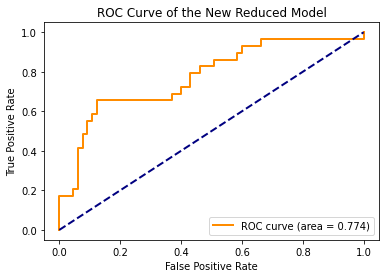

```python
def plot_roc(fpr, tpr, auc, lw=2):
    plt.plot(fpr, tpr, color='darkorange', lw=lw,
             label='ROC curve (area = '+str(round(auc,3))+')')
    plt.plot([0, 1], [0, 1], color='navy', lw=lw, linestyle='--')
    plt.xlabel('False Positive Rate')
    plt.ylabel('True Positive Rate')
    plt.title('ROC Curve of the New Reduced Model')
    plt.legend(loc="lower right")
    plt.show()

plot_roc(fpr_full, tpr_full, auc_full)
```

#### Final Model

```python
final_mod = smf.logit('y_hiphop ~ Danceability + Loudness + Speechiness + Acousticness + Liveness + Valence', data = df_train).fit()

phat_test = final_mod.predict(exog=df_test)
phat_test.head(10)
```

```
Optimization terminated successfully.
         Current function value: 0.477334
         Iterations 6
```

```
248    0.429256
292    0.122217
494    0.634598
457    0.341225
261    0.117467
98     0.308074
232    0.122402
75     0.358142
250    0.097517
354    0.113067
dtype: float64
```

```python
fpr_full, tpr_full, score_full = roc_curve(y_true=df_test['y_hiphop'], y_score=df_test['phat_test'])
auc_full = roc_auc_score(y_true=df_test['y_hiphop'], y_score=df_test['phat_test'])
```

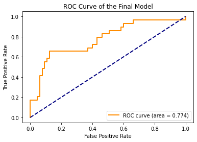

```python
def plot_roc(fpr, tpr, auc, lw=2):
    plt.plot(fpr, tpr, color='darkorange', lw=lw,
             label='ROC curve (area = '+str(round(auc,3))+')')
    plt.plot([0, 1], [0, 1], color='navy', lw=lw, linestyle='--')
    plt.xlabel('False Positive Rate')
    plt.ylabel('True Positive Rate')
    plt.title('ROC Curve of the Final Model')
    plt.legend(loc="lower right")
    plt.show()

plot_roc(fpr_full, tpr_full, auc_full)
```

### Predictive Probability Thresholds Selection

```python
from sklearn.metrics import confusion_matrix

def tpr_fpr_thresh(y, pred_prob, thresh):
    yhat = 1*(pred_prob >= thresh)
    tn, fp, fn, tp = confusion_matrix(y_true=y, y_pred=yhat).ravel()
    tpr = tp / (fn + tp)
    fpr = fp / (fp + tn)
    return pd.DataFrame({'threshold':[thresh],
                         'tpr':[tpr],
                         'fpr':[fpr]})
```

```python
for thresh in np.arange(0,1,.01):
    print(tpr_fpr_thresh(df_test['y_hiphop'], df_test['phat_test'], thresh))
```

```
   threshold  tpr  fpr
0        0.0  1.0  1.0
   threshold  tpr  fpr
0       0.01  1.0  1.0
   threshold  tpr  fpr
0       0.02  1.0  1.0
   threshold       tpr  fpr
0       0.03  0.965517  1.0
   threshold       tpr       fpr
0       0.04  0.965517  0.984615
   threshold       tpr       fpr
0       0.05  0.965517  0.953846
   threshold       tpr       fpr
0       0.06  0.965517  0.907692
   threshold       tpr       fpr
0       0.07  0.965517  0.876923
   threshold       tpr       fpr
0       0.08  0.965517  0.846154
   threshold       tpr       fpr
0       0.09  0.965517  0.753846
   threshold       tpr       fpr
0        0.1  0.965517  0.738462
   threshold       tpr       fpr
0       0.11  0.965517  0.738462
   threshold       tpr       fpr
0       0.12  0.965517  0.692308
   threshold       tpr       fpr
0       0.13  0.931034  0.661538
   threshold       tpr       fpr
0       0.14  0.931034  0.630769
   threshold       tpr       fpr
0       0.15  0.896552  0.584615
   threshold       tpr       fpr
0       0.16  0.862069  0.538462
   threshold       tpr       fpr
0       0.17  0.827586  0.507692
   threshold       tpr       fpr
0       0.18  0.827586  0.461538
   threshold       tpr       fpr
0       0.19  0.793103  0.461538
```

[output cut: 145 more lines]

```
0       0.92  0.0  0.0
   threshold  tpr  fpr
0       0.93  0.0  0.0
   threshold  tpr  fpr
0       0.94  0.0  0.0
   threshold  tpr  fpr
0       0.95  0.0  0.0
   threshold  tpr  fpr
0       0.96  0.0  0.0
   threshold  tpr  fpr
0       0.97  0.0  0.0
   threshold  tpr  fpr
0       0.98  0.0  0.0
   threshold  tpr  fpr
0       0.99  0.0  0.0
```

Tying with our research questions, we may think of a scenario such as:

Suppose we are working as data scientists at Spotify. Many different music awards shows are held every year, and songs are nominated and awarded from different genres. We would like to evaluate whether a song in the Spotify Top 200 chart can be considered as hip hop or not and create a nomination list of hip hop songs based on the classification that we made. However, we would be penalized when labeling a song's genre incorrectly. Considering our goal is to have a possibility of mislabeling as low as possible, we should therefore focus more of having lower false positive rate rather than higher true positive rate.

Comparing all threshold values above, the threshold of $p_0 = 0.4$ seems to have the most reasonable and best trade-off between false and true positive rate.

(False Positive Rate = 0.123, True Positive Rate = 0.66)

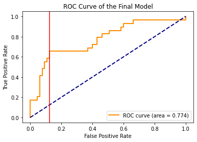

```python
fpr_full, tpr_full, score_full = roc_curve(y_true=df_test['y_hiphop'], y_score=df_test['phat_test'])
auc_full = roc_auc_score(y_true=df_test['y_hiphop'], y_score=df_test['phat_test'])

plt.plot(fpr_full, tpr_full, color='darkorange', lw=2, label='ROC curve (area = '+str(round(auc_full,3))+')')
plt.plot([0, 1], [0, 1], color='navy', lw=2, linestyle='--')
plt.xlabel('False Positive Rate')
plt.ylabel('True Positive Rate')

# Vertical Line = x = 0.123 (x-axis = False Positive Rate) when threshold p0 = 0.4
plt.axvline(x=0.123, color='r', linestyle='-')
plt.title('ROC Curve of the Final Model')
plt.legend(loc="lower right")
plt.show()
```

## 6. Conclusion

Throughout the diverse analyses above, we have found some interesting results:

- People tend to prefer more of listening to songs with lower energy (relatively 'soft' or 'quiet' songs) in the fall whereas more energetic songs are favored by people in the other three seasons.
- While it may be easy to think that a song with lower energy might be slower (tempo), there is no difference of a song's tempo that was released in the summer and fall on average.
- Except that the linear regression conditions are not met, it is significant that a song's artist features (Number of Times Charted, Followers, Streams, Popularity) do affect the song's highest charting position.
- Assuming the music components (explanatory variables) in the logistic model to have about the same values, we would expect 'Danceability' and 'Speechiness' to be the most influential variables when it comes to determining whether a song is hip hop or not due to large slope coefficients.

Since there are several columns that are related to time and date (ex. **'Released_Date_month'**, **'Weeks_Charted_day'**), we could do more deep analysis related to 'Time Series' although we have not learned yet. For instance, we may inquire 'Are there any detectable trends in this dataset that might reflect some significant events happened in 2020 and 2021?'

## Contribution Report

1. Chulong Cheng - Introduction / Descriptive Analysis / Inference
2. Minjae Gil - Introduction / Data Preprocessing / Linear Regression
3. Junseok Yang - Introduction / Logistic Regression / Conclusion